# Combined use of eDNA metabarcoding and visual surveys to monitor rocky intertidal biodiversity

Author

Simons D-L, Hipperson H, Webb TJ, Spencer M, Mieszkowska N

## Introduction

This pipeline replicates all analyses in Simons *et al* (2025) “Combined use of eDNA metabarcoding and visual surveys to monitor rocky intertidal biodiversity”.

## Load packages

Some packages require installation from Bioconductor using the `BiocManager::install()` command.

```r
#clear environment
rm(list = ls())

#define packages
packages <- c("dplyr",
              "devtools",
              "microbiome", #BiocManager install
              "tidyverse",
              "vegan",
              "phyloseq", #BiocManager install
              "eulerr",
              "cowplot",
              "ggVennDiagram",
              'lme4',
              "car",
              "emmeans",
              "ggpattern",
              "ggrepel",
              "sf",
              "ggtext",
              "ComplexHeatmap", #BiocManager install
              "microViz" #github install
              )

new.packages <- packages[!(packages %in% installed.packages()[,"Package"])]
if(length(new.packages)) install.packages(new.packages)

invisible(lapply(packages, library, character.only = TRUE))
```

## Importing data and tidying

Let’s load our phyloseq object and long data, which have already been tidied, decontaminated, filtered for target taxa, and checked for quality control through [this pipeline](https://github.com/dinaleighsimons/intertidal-eDNA-formatting-and-quality-control).

```r
visual <- read.csv("Input_Data/rocky_visual_data.csv")
eDNA <- read.csv("Input_Data/rocky_eDNA_long.csv", row.names = 1)

load("Input_Data/phylo_MarClim.RData")
load("Input_Data/phylo_rocky_eDNA.RData")
```

Let’s first explore our two `phyloseq` objects.

```r
phylo_MarClim
```

```
phyloseq-class experiment-level object
otu_table()   OTU Table:         [ 86 taxa and 29 samples ]
sample_data() Sample Data:       [ 29 samples by 3 sample variables ]
tax_table()   Taxonomy Table:    [ 86 taxa by 8 taxonomic ranks ]
```

```r
phylo_rocky_eDNA
```

```
phyloseq-class experiment-level object
otu_table()   OTU Table:         [ 1026 taxa and 505 samples ]
sample_data() Sample Data:       [ 505 samples by 42 sample variables ]
tax_table()   Taxonomy Table:    [ 1026 taxa by 13 taxonomic ranks ]
```

The eDNA data contains sites which visual surveys weren’t conducted at. Let’s remove them.

```r
# define sites with no visual survey
sites_no_visual <- c("Borwick, Yesnaby", "Martin's Haven", "Skomer Island")

# subset the long
eDNA <- subset(eDNA, !verbatimLocality %in% sites_no_visual)

# subset the phylo object
phylo_rocky_eDNA <- subset_samples(phylo_rocky_eDNA,
                                        !verbatimLocality %in% sites_no_visual)
phylo_rocky_eDNA
```

```
phyloseq-class experiment-level object
otu_table()   OTU Table:         [ 1026 taxa and 482 samples ]
sample_data() Sample Data:       [ 482 samples by 42 sample variables ]
tax_table()   Taxonomy Table:    [ 1026 taxa by 13 taxonomic ranks ]
```

We need to fix some names so that they match in both data sets.

```r
# fix unmatched names in long eDNA
eDNA$valid_name[eDNA$valid_name == "Mytilus"] <- "Mytilus spp"
eDNA$valid_name[eDNA$valid_name == "Mytilus edulis"] <- "Mytilus spp"
eDNA$valid_name[eDNA$valid_name == "Codium"] <- "Codium spp"
eDNA$valid_name[eDNA$valid_name == "Steromphala umbilicaris"] <- "Steromphala umbilicalis"

# fix unmatched names in long visual
visual$valid_name[visual$valid_name == "Mytilus"] <- "Mytilus spp"
visual$valid_name[visual$valid_name == "Codium"] <- "Codium spp"
```

### Combine (indirect, long)

First, let’s match the capitalization of the names.

```r
# correct capitalisation in visual (long)
visual$sciname <- sapply(strsplit(visual$sciname, " "),
                         #split taxa into two
                         function(x)
                           paste(toupper(substr(x[1], 1, 1)) %>% #converts genus to upper
                                   paste0(tolower(
                                     substr(x[1], 2, nchar(x[1]))
                                   )), tolower(paste(x[-1], collapse = " "))))

# correct capitalisation in visual (phylo)
taxa_names(phylo_MarClim) <- sapply(taxa_names(phylo_MarClim), function(x) {
  paste(toupper(substring(x, 1, 1)), tolower(substring(x, 2)), sep = "")
})

# Round up or down the numeric conversions for phyloseq objects
otu_table(phylo_MarClim) <- round(otu_table(phylo_MarClim))
otu_table(phylo_rocky_eDNA) <- round(otu_table(phylo_rocky_eDNA))
```

Let’s filter the eDNA data using the visual survey species list. For the indirect matches, we are going to keep all the taxa which match any of the taxa listed in the MarClim list at all levels. This means we’ll get a broader range of species within the eDNA data set compared to visual at higher taxonomic levels.

```r
# make names factors
visual$valid_name <- as.factor(visual$valid_name)
eDNA$valid_name <- as.factor(eDNA$valid_name)

# long - match to species, genus, family
visual_species <- unique(visual$valid_name)
eDNA_species <- subset(eDNA, valid_name %in% visual_species)
dim(eDNA_species)
```

```
[1] 20244    57
```

```r
visual_genera <- unique(visual$genus)
eDNA_genus <- subset(eDNA, genus %in% visual_genera)
dim(eDNA_genus)
```

```
[1] 31330    57
```

```r
visual_family <- unique(visual$family)
eDNA_family <- subset(eDNA, family %in% visual_family)
dim(eDNA_family)
```

```
[1] 59286    57
```

```r
visual_phylum <- unique(visual$phylum)
eDNA_phylum <- subset(eDNA, phylum %in% visual_phylum)
dim(eDNA_phylum)
```

```
[1] 453080     57
```

Species-level combining.

First, let’s format the visual data so we combine it later on.

```r
## select relevant columns
visual_subset <- visual %>% dplyr::select(c(
  valid_name,
  localityID,
  Count,
  country,
  genus,
  verbatimLocality,
  phylum
))

## add method column
visual_subset$method <- "Visual"

## rename columns
colnames(visual_subset) <- c("taxa", "localityID", "count", "region", "genus", "site", "phylum", "method")

## add columns which are needed later for the eDNA joining
visual_subset <- visual_subset %>%
  mutate(pa = ifelse(count > 0, 1, 0),
         num_samples = NA,
         num_samples_found = NA,
         prop_samples_found = NA)
```

```r
# Calculate number of samples which detected each species per site

## create pa variable
eDNA_species <- eDNA_species %>%
  mutate(pa = ifelse(reads > 0, 1, 0))

## Convert multiple columns to factor
eDNA_species <- eDNA_species %>%
  mutate(
    localityID = factor(localityID),
    fullID = factor(fullID),
    sampleType = factor(sampleType),
    taxa = factor(valid_name)
  )

## summarise to calculate proportions of detection at a site level
eDNA_site_level <- eDNA_species %>%
    dplyr::group_by(localityID, valid_name) %>%  # Group by site and taxa
    dplyr::summarise(
        num_samples = n_distinct(fullID),
        num_samples_found = n_distinct(fullID[pa > 0]),
        prop_samples_found = num_samples_found /num_samples
    ) %>%
    ungroup()

## rename columns
colnames(eDNA_site_level) <- c("localityID", "taxa", "num_samples", "num_samples_found", "prop_samples_found")

## get columns of interest
eDNA_subset <- eDNA_species %>% dplyr::select(c(
  valid_name,
  localityID,
  reads,
  country,
  genus,
  verbatimLocality,
  pa,
  phylum
))

## rename columns
colnames(eDNA_subset) <- c("taxa",
                           "localityID",
                           "count",
                           "region",
                           "genus",
                           "site",
                           "pa",
                           "phylum")

## sum number of reads
eDNA_subset_site <- eDNA_subset %>%
  dplyr::group_by(localityID, taxa) %>% # can add primer here if interested
  dplyr::summarise(
    count = sum(count))

## add method
eDNA_subset_site$method <- "eDNA"

## join proportions and summed counts together
eDNA_join <- left_join(eDNA_subset_site,
                       eDNA_site_level,
                       by = c("taxa", "localityID"))

## get meta data back and add in
eDNA_subset_meta <- eDNA_subset %>% dplyr::select(c(localityID, region, genus, taxa, site, phylum)) %>%
  unique()

eDNA_join_meta <- left_join(eDNA_join,
                       eDNA_subset_meta,
                       by = c("taxa", "localityID"))

## recalculate PA
eDNA_join_meta <- eDNA_join_meta %>%
  mutate(pa = ifelse(count > 0, 1, 0))

## select relevant columns only for the final data
eDNA_join_final <- eDNA_join_meta %>%  select(c(taxa, localityID, count, region, genus, site, phylum, method, pa, num_samples, num_samples_found, prop_samples_found))

## check pa and counts align
any(eDNA_join_final$num_samples_found > 0 & eDNA_join_final$count == 0) #should be false
```

```
[1] FALSE
```

```r
# check columns align - should all be true
colnames(visual_subset) == colnames(eDNA_join_final)
```

```
 [1] TRUE TRUE TRUE TRUE TRUE TRUE TRUE TRUE TRUE TRUE TRUE TRUE
```

```r
# combine
combined_data<- rbind(visual_subset, eDNA_join_final)

# remove any white space
combined_data$taxa <- trimws(combined_data$taxa)

# remove any duplicates
combined_data <- unique(combined_data)

# fix rogue name
combined_data$taxa <- gsub("Halichondria \\(Halichondria\\) panicea", "Halichondria panicea", combined_data$taxa)

# save
write.csv(combined_data, "Processed_data/combined_methods_long_data.csv")
```

Genus-level combining.

First, let’s format the visual data to genus level so we combine it later on.

```r
# select relevant columns
visual_subset_genus <- visual %>% dplyr::select(c(
  valid_name,
  localityID,
  Count,
  country,
  genus,
  verbatimLocality,
  phylum
))

# add method column
visual_subset_genus$method <- "Visual"

# rename columns
colnames(visual_subset_genus) <- c("taxa", "localityID", "count", "region", "genus", "site", "phylum", "method")

# Compute unique present taxa per genus + site
num_taxa_summary <- visual_subset_genus %>%
  filter(count > 0) %>%
  group_by(genus, site) %>%
  summarise(num_taxa_unique = n_distinct(taxa), .groups = "drop")

# add observations from different species but same genus together, cal richness
visual_subset_genus <- visual_subset_genus %>%
  group_by(genus, site) %>%
  summarise(
    localityID = first(localityID),
    count = sum(count),
    region = first(region),
    phylum = first(phylum),
    method = first(method),
    .groups = 'drop'
  )

# Join back to original data (keeps absences)
visual_subset_genus <- visual_subset_genus %>%
  left_join(num_taxa_summary, by = c("genus", "site")) %>%
  mutate(num_taxa_unique = replace_na(num_taxa_unique, 0))

# correct the order of columns
visual_subset_genus <- visual_subset_genus %>%
  select(localityID, count, region, genus, site, phylum, method,num_taxa_unique)

# add columns which are needed later for the eDNA joining
visual_subset_genus <- visual_subset_genus %>%
  mutate(pa = ifelse(count > 0, 1, 0),
         num_samples = NA,
         num_samples_found = NA,
         prop_samples_found = NA)
```

```r
# Calculate number of samples which detected each species per site

## create pa variable
eDNA_genus <- eDNA_genus %>%
  mutate(pa = ifelse(reads > 0, 1, 0))

## Convert multiple columns to factor
eDNA_genus <- eDNA_genus %>%
  mutate(
    taxa = factor(taxa),
    localityID = factor(localityID),
    fullID = factor(fullID),
    sampleType = factor(sampleType),
    genus = factor(genus)
  )

## summarise to calculate proportions of detection at a site level
eDNA_site_level_genus <- eDNA_genus %>%
    dplyr::group_by(localityID, genus) %>%  # Group by site and taxa
    dplyr::summarise(
        num_samples = n_distinct(fullID),
        num_samples_found = n_distinct(fullID[pa > 0]),
        prop_samples_found = num_samples_found /num_samples
    ) %>%
    ungroup()

## rename columns
colnames(eDNA_site_level_genus) <- c("localityID", "genus", "num_samples", "num_samples_found", "prop_samples_found")

## get columns of interest
eDNA_subset_genus <- eDNA_genus %>% dplyr::select(c(
    valid_name,
    localityID,
    reads,
    country,
    genus,
    verbatimLocality,
    pa,
    phylum
  ))

## rename columns
colnames(eDNA_subset_genus) <- c("taxa",
                                 "localityID",
                                 "count",
                                 "region",
                                 "genus",
                                 "site",
                                 "pa",
                                 "phylum")

## add method
eDNA_subset_genus$method <- "eDNA"

# Compute unique present taxa per genus + site
num_taxa_summary_genus <- eDNA_subset_genus %>%
  filter(count > 0) %>%
  group_by(genus, site) %>%
  summarise(num_taxa_unique = n_distinct(taxa), .groups = "drop")

# add observations from different species but same genus together, cal richness
eDNA_subset_genus <- eDNA_subset_genus %>%
  group_by(genus, site) %>%
  summarise(
    localityID = first(localityID),
    count = sum(count),
    region = first(region),
    phylum = first(phylum),
    method = first(method),
    .groups = 'drop'
  )

# Join back to original data (keeps absences)
eDNA_subset_genus <- eDNA_subset_genus %>%
  left_join(num_taxa_summary_genus, by = c("genus", "site")) %>%
  mutate(num_taxa_unique = replace_na(num_taxa_unique, 0))

## join proportions and summed counts together
eDNA_join_genus <- left_join(eDNA_subset_genus,
                              eDNA_site_level_genus,
                              by = c("genus", "localityID")) %>%
  mutate(pa = ifelse(count > 0, 1, 0))

## select relevant columns only for the final data
eDNA_join_final_genus <- eDNA_join_genus %>%  select(c(localityID, count, region, genus, site, phylum, method, num_taxa_unique, pa, num_samples, num_samples_found, prop_samples_found))

## check pa and counts align
any(eDNA_join_final_genus$num_samples_found > 0 & eDNA_join_final_genus$count == 0) #should be false
```

```
[1] FALSE
```

```r
# check columns align - should all be true
colnames(visual_subset_genus) == colnames(eDNA_join_final_genus)
```

```
 [1] TRUE TRUE TRUE TRUE TRUE TRUE TRUE TRUE TRUE TRUE TRUE TRUE
```

```r
# combine
combined_data_genus<- rbind(visual_subset_genus, eDNA_join_final_genus)

# remove any white space
combined_data_genus$genus <- trimws(combined_data_genus$genus)

# remove any duplicates
combined_data_genus <- unique(combined_data_genus)
```

Family-level combining.

First, let’s format the visual data to family level so we combine it later on.

```r
# select relevant columns
visual_subset_family <- visual %>% dplyr::select(c(
  valid_name,
  localityID,
  Count,
  country,
  family,
  verbatimLocality,
  phylum
))

# add method column
visual_subset_family$method <- "Visual"

# rename columns
colnames(visual_subset_family) <- c("taxa", "localityID", "count", "region", "family", "site", "phylum", "method")

# Compute unique present taxa per family + site
num_taxa_summary <- visual_subset_family %>%
  filter(count > 0) %>%
  group_by(family, site) %>%
  summarise(num_taxa_unique = n_distinct(taxa), .groups = "drop")

# add observations from different species but same family together, cal richness
visual_subset_family <- visual_subset_family %>%
  group_by(family, site) %>%
  summarise(
    localityID = first(localityID),
    count = sum(count),
    region = first(region),
    phylum = first(phylum),
    method = first(method),
    .groups = 'drop'
  )

# Join back to original data (keeps absences)
visual_subset_family <- visual_subset_family %>%
  left_join(num_taxa_summary, by = c("family", "site")) %>%
  mutate(num_taxa_unique = replace_na(num_taxa_unique, 0))

# correct the order of columns
visual_subset_family <- visual_subset_family %>%
  select(localityID, count, region, family, site, phylum, method,num_taxa_unique)

# add columns which are needed later for the eDNA joining
visual_subset_family <- visual_subset_family %>%
  mutate(pa = ifelse(count > 0, 1, 0),
         num_samples = NA,
         num_samples_found = NA,
         prop_samples_found = NA)
```

```r
# Calculate number of samples which detected each species per site

## create pa variable
eDNA_family <- eDNA_family %>%
  mutate(pa = ifelse(reads > 0, 1, 0))

## Convert multiple columns to factor
eDNA_family <- eDNA_family %>%
  mutate(
    taxa = factor(taxa),
    localityID = factor(localityID),
    fullID = factor(fullID),
    sampleType = factor(sampleType),
    family = factor(family)
  )

## summarise to calculate proportions of detection at a site level
eDNA_site_level_family <- eDNA_family %>%
    dplyr::group_by(localityID, family) %>%  # Group by site and taxa
    dplyr::summarise(
        num_samples = n_distinct(fullID),
        num_samples_found = n_distinct(fullID[pa > 0]),
        prop_samples_found = num_samples_found /num_samples
    ) %>%
    ungroup()

## rename columns
colnames(eDNA_site_level_family) <- c("localityID", "family", "num_samples", "num_samples_found", "prop_samples_found")

## get columns of interest
eDNA_subset_family <- eDNA_family %>% dplyr::select(c(
    valid_name,
    localityID,
    reads,
    country,
    family,
    verbatimLocality,
    pa,
    phylum
  ))

## rename columns
colnames(eDNA_subset_family) <- c("taxa",
                                 "localityID",
                                 "count",
                                 "region",
                                 "family",
                                 "site",
                                 "pa",
                                 "phylum")

## add method
eDNA_subset_family$method <- "eDNA"

# Compute unique present taxa per family + site
num_taxa_summary_family <- eDNA_subset_family %>%
  filter(count > 0) %>%
  group_by(family, site) %>%
  summarise(num_taxa_unique = n_distinct(taxa), .groups = "drop")

# add observations from different species but same family together, cal richness
eDNA_subset_family <- eDNA_subset_family %>%
  group_by(family, site) %>%
  summarise(
    localityID = first(localityID),
    count = sum(count),
    region = first(region),
    phylum = first(phylum),
    method = first(method),
    .groups = 'drop'
  )

# Join back to original data (keeps absences)
eDNA_subset_family <- eDNA_subset_family %>%
  left_join(num_taxa_summary_family, by = c("family", "site")) %>%
  mutate(num_taxa_unique = replace_na(num_taxa_unique, 0))

## join proportions and summed counts together
eDNA_join_family <- left_join(eDNA_subset_family,
                              eDNA_site_level_family,
                              by = c("family", "localityID")) %>%
  mutate(pa = ifelse(count > 0, 1, 0))

## select relevant columns only for the final data
eDNA_join_final_family <- eDNA_join_family %>%  select(c(localityID, count, region, family, site, phylum, method, num_taxa_unique, pa, num_samples, num_samples_found, prop_samples_found))

## check pa and counts align
any(eDNA_join_final_family$num_samples_found > 0 & eDNA_join_final_family$count == 0) #should be false
```

```
[1] FALSE
```

```r
# check columns align - should all be true
colnames(visual_subset_family) == colnames(eDNA_join_final_family)
```

```
 [1] TRUE TRUE TRUE TRUE TRUE TRUE TRUE TRUE TRUE TRUE TRUE TRUE
```

```r
# combine
combined_data_family<- rbind(visual_subset_family, eDNA_join_final_family)

# remove any white space
combined_data_family$family <- trimws(combined_data_family$family)

# remove any duplicates
combined_data_family <- unique(combined_data_family)
```

Phylum level

```r
# select relevant columns
visual_subset_phylum <- visual %>% dplyr::select(c(
  valid_name,
  localityID,
  Count,
  country,
  phylum,
  verbatimLocality,
))

# add method column
visual_subset_phylum$method <- "Visual"

# rename columns
colnames(visual_subset_phylum) <- c("taxa", "localityID", "count", "region", "phylum", "site", "method")

# Compute unique present taxa per phylum + site
num_taxa_summary <- visual_subset_phylum %>%
  filter(count > 0) %>%
  group_by(phylum, site) %>%
  summarise(num_taxa_unique = n_distinct(taxa), .groups = "drop")

# add observations from different species but same phylum together, cal richness
visual_subset_phylum <- visual_subset_phylum %>%
  group_by(phylum, site) %>%
  summarise(
    localityID = first(localityID),
    count = sum(count),
    region = first(region),
    method = first(method),
    .groups = 'drop'
  )

# Join back to original data (keeps absences)
visual_subset_phylum <- visual_subset_phylum %>%
  left_join(num_taxa_summary, by = c("phylum", "site")) %>%
  mutate(num_taxa_unique = replace_na(num_taxa_unique, 0))

# correct the order of columns
visual_subset_phylum <- visual_subset_phylum %>%
  select(localityID, count, region, phylum, site, method,num_taxa_unique)

# add columns which are needed later for the eDNA joining
visual_subset_phylum <- visual_subset_phylum %>%
  mutate(pa = ifelse(count > 0, 1, 0),
         num_samples = NA,
         num_samples_found = NA,
         prop_samples_found = NA)
```

```r
# Calculate number of samples which detected each species per site

## create pa variable
eDNA_phylum <- eDNA_phylum %>%
  mutate(pa = ifelse(reads > 0, 1, 0))

## Convert multiple columns to factor
eDNA_phylum <- eDNA_phylum %>%
  mutate(
    taxa = factor(taxa),
    localityID = factor(localityID),
    fullID = factor(fullID),
    sampleType = factor(sampleType),
    phylum = factor(phylum)
  )

## summarise to calculate proportions of detection at a site level
eDNA_site_level_phylum <- eDNA_phylum %>%
    dplyr::group_by(localityID, phylum) %>%  # Group by site and taxa
    dplyr::summarise(
        num_samples = n_distinct(fullID),
        num_samples_found = n_distinct(fullID[pa > 0]),
        prop_samples_found = num_samples_found /num_samples
    ) %>%
    ungroup()

## rename columns
colnames(eDNA_site_level_phylum) <- c("localityID", "phylum", "num_samples", "num_samples_found", "prop_samples_found")

## get columns of interest
eDNA_subset_phylum <- eDNA_phylum %>% dplyr::select(c(
    valid_name,
    localityID,
    reads,
    country,
    phylum,
    verbatimLocality,
    pa
  ))

## rename columns
colnames(eDNA_subset_phylum) <- c("taxa",
                                 "localityID",
                                 "count",
                                 "region",
                                 "phylum",
                                 "site",
                                 "pa")

## add method
eDNA_subset_phylum$method <- "eDNA"

# Compute unique present taxa per phylum + site
num_taxa_summary_phylum <- eDNA_subset_phylum %>%
  filter(count > 0) %>%
  group_by(phylum, site) %>%
  summarise(num_taxa_unique = n_distinct(taxa), .groups = "drop")

# add observations from different species but same phylum together, cal richness
eDNA_subset_phylum <- eDNA_subset_phylum %>%
  group_by(phylum, site) %>%
  summarise(
    localityID = first(localityID),
    count = sum(count),
    region = first(region),
    method = first(method),
    .groups = 'drop'
  )

# Join back to original data (keeps absences)
eDNA_subset_phylum <- eDNA_subset_phylum %>%
  left_join(num_taxa_summary_phylum, by = c("phylum", "site")) %>%
  mutate(num_taxa_unique = replace_na(num_taxa_unique, 0))

## join proportions and summed counts together
eDNA_join_phylum <- left_join(eDNA_subset_phylum,
                              eDNA_site_level_phylum,
                              by = c("phylum", "localityID")) %>%
  mutate(pa = ifelse(count > 0, 1, 0))

## select relevant columns only for the final data
eDNA_join_final_phylum <- eDNA_join_phylum %>%  select(c(localityID, count, region, phylum, site, method, num_taxa_unique, pa, num_samples, num_samples_found, prop_samples_found))

## check pa and counts align
any(eDNA_join_final_phylum$num_samples_found > 0 & eDNA_join_final_phylum$count == 0) #should be false
```

```
[1] FALSE
```

```r
# check columns align - should all be true
colnames(visual_subset_phylum) == colnames(eDNA_join_final_phylum)
```

```
 [1] TRUE TRUE TRUE TRUE TRUE TRUE TRUE TRUE TRUE TRUE TRUE
```

```r
# combine
combined_data_phylum<- rbind(visual_subset_phylum, eDNA_join_final_phylum)

# remove any white space
combined_data_phylum$phylum <- trimws(combined_data_phylum$phylum)

# remove any duplicates
combined_data_phylum <- unique(combined_data_phylum)
```

We now have four version of combined datasets representing indirect matches.

```r
head(combined_data)
```

```
            taxa localityID    count            region   genus         site
1 Actinia equina       CN01 5.000004 Southwest England Actinia Lizard Point
2 Actinia equina       CN02 5.000004 Southwest England Actinia  Sennen Cove
3 Actinia equina       CN03 3.000434 Southwest England Actinia         Looe
4 Actinia equina       CN04 3.000434 Southwest England Actinia      St Ives
5 Actinia equina       CN05 2.004321 Southwest England Actinia      Trevone
6 Actinia equina       NE01 4.000043 Northeast England Actinia  Filey Brigg
    phylum method pa num_samples num_samples_found prop_samples_found
1 Cnidaria Visual  1          NA                NA                 NA
2 Cnidaria Visual  1          NA                NA                 NA
3 Cnidaria Visual  1          NA                NA                 NA
4 Cnidaria Visual  1          NA                NA                 NA
5 Cnidaria Visual  1          NA                NA                 NA
6 Cnidaria Visual  1          NA                NA                 NA
```

```r
head(combined_data_genus)
```

```
# A tibble: 6 × 12
  localityID count region        genus site  phylum method num_taxa_unique    pa
  <chr>      <dbl> <chr>         <chr> <chr> <chr>  <chr>            <int> <dbl>
1 SW01        4.04 South Wales   Acti… Aber… Cnida… Visual               2     1
2 SW03        5.00 South Wales   Acti… Broa… Cnida… Visual               1     1
3 NE05        3.00 Northeast En… Acti… Cast… Cnida… Visual               1     1
4 SW07        2.00 South Wales   Acti… Dale… Cnida… Visual               1     1
5 NE01        4.00 Northeast En… Acti… File… Cnida… Visual               1     1
6 NW02        3.00 North Wales   Acti… Grea… Cnida… Visual               1     1
# ℹ 3 more variables: num_samples <int>, num_samples_found <int>,
#   prop_samples_found <dbl>
```

```r
head(combined_data_family)
```

```
# A tibble: 6 × 12
  localityID count region       family site  phylum method num_taxa_unique    pa
  <chr>      <dbl> <chr>        <chr>  <chr> <chr>  <chr>            <int> <dbl>
1 SW01        7.04 South Wales  Actin… Aber… Cnida… Visual               3     1
2 SW03        7.00 South Wales  Actin… Broa… Cnida… Visual               2     1
3 NE05        3.00 Northeast E… Actin… Cast… Cnida… Visual               1     1
4 SW07        4.01 South Wales  Actin… Dale… Cnida… Visual               2     1
5 NE01        4.00 Northeast E… Actin… File… Cnida… Visual               1     1
6 NW02        3.00 North Wales  Actin… Grea… Cnida… Visual               1     1
# ℹ 3 more variables: num_samples <int>, num_samples_found <int>,
#   prop_samples_found <dbl>
```

```r
head(combined_data_phylum)
```

```
# A tibble: 6 × 11
  localityID count region  phylum site  method num_taxa_unique    pa num_samples
  <chr>      <dbl> <chr>   <chr>  <chr> <chr>            <int> <dbl>       <int>
1 SW01           0 South … Annel… Aber… Visual               0     0          NA
2 SW03           0 South … Annel… Broa… Visual               0     0          NA
3 NE05           0 Northe… Annel… Cast… Visual               0     0          NA
4 SW07           0 South … Annel… Dale… Visual               0     0          NA
5 NE01           0 Northe… Annel… File… Visual               0     0          NA
6 NW02           0 North … Annel… Grea… Visual               0     0          NA
# ℹ 2 more variables: num_samples_found <int>, prop_samples_found <dbl>
```

### Combine (indirect, `phyloseq`)

Now let’s make the combined `phyloseq` object.

Species-level.

```r
# phylo - match to species, genus, family and phylum
visual_family <- unique(visual$family)
visual_phyla <- unique(visual$phylum)

# species
phylo_rocky_eDNA_marlcim_species <- subset_taxa(phylo_rocky_eDNA,
                                        valid_name %in% visual_species)
phylo_rocky_eDNA_marlcim_species
```

```
phyloseq-class experiment-level object
otu_table()   OTU Table:         [ 39 taxa and 482 samples ]
sample_data() Sample Data:       [ 482 samples by 42 sample variables ]
tax_table()   Taxonomy Table:    [ 39 taxa by 13 taxonomic ranks ]
```

```r
# formatting eDNA phylo
phylo_eDNA_merge <- phylo_rocky_eDNA_marlcim_species
sample_data(phylo_eDNA_merge)$Method <- "eDNA"
sample_data(phylo_eDNA_merge)$methodsite_id <- paste(sample_data(phylo_eDNA_merge)$localityID, sample_data(phylo_eDNA_merge)$Method, sep = "_")

# reduce eDNA sample data
sd <- sample_data(phylo_eDNA_merge) %>% data.frame()
sd <- sd[, names(sd) %in% c("localityID", "country", "verbatimLocality", "Method", "methodsite_id")]
sd$localityID <- as.factor(sd$localityID)
sd$country <- as.factor(sd$country)
sd$Method <- as.factor(sd$Method)
sd$verbatimLocality <- as.factor(sd$verbatimLocality)
sd$methodsite_id <- as.factor(sd$methodsite_id)
rownames(sd) <- NULL
sd <- sd[!duplicated(sd), ]
rownames(sd) <- sd$methodsite_id

# merge DNA samples by sites
ps_edna_site <- merge_samples(phylo_eDNA_merge, group = "methodsite_id")
sample_data(ps_edna_site) <- sd

# formatting visual
phylo_visual_merge <- phylo_MarClim
sample_data(phylo_visual_merge)$Method <- "Visual"
sample_data(phylo_visual_merge)$methodsite_id <- paste(sample_data(phylo_visual_merge)$localityID, sample_data(phylo_visual_merge)$Method, sep = "_")
sample_names(phylo_visual_merge) <- sample_data(phylo_visual_merge)$methodsite_id

sample_data(phylo_visual_merge)$localityID <- as.factor(sample_data(phylo_visual_merge)$localityID)
sample_data(phylo_visual_merge)$country <- as.factor(sample_data(phylo_visual_merge)$country)
sample_data(phylo_visual_merge)$Method <- as.factor(sample_data(phylo_visual_merge)$Method)
sample_data(phylo_visual_merge)$verbatimLocality <- as.factor(sample_data(phylo_visual_merge)$verbatimLocality)
sample_data(phylo_visual_merge)$methodsite_id <- as.factor(sample_data(phylo_visual_merge)$methodsite_id)

# merge together
ps_merged <- merge_phyloseq(phylo_visual_merge, ps_edna_site)
ps_merged
```

```
phyloseq-class experiment-level object
otu_table()   OTU Table:         [ 87 taxa and 58 samples ]
sample_data() Sample Data:       [ 58 samples by 5 sample variables ]
tax_table()   Taxonomy Table:    [ 87 taxa by 14 taxonomic ranks ]
```

```r
ps_merged_pa <- microViz::tax_transform(ps_merged, trans = "pa")

# Remove any taxa without occurances
ps_merged_pa <- subset_taxa(ps_merged_pa, taxa_sums(ps_merged_pa) > 0)
```

Genus-level.

```r
# genus
phylo_rocky_eDNA_marlcim_genus <- subset_taxa(phylo_rocky_eDNA,
                                        genus %in% visual_genera)
phylo_rocky_eDNA_marlcim_genus
```

```
phyloseq-class experiment-level object
otu_table()   OTU Table:         [ 65 taxa and 482 samples ]
sample_data() Sample Data:       [ 482 samples by 42 sample variables ]
tax_table()   Taxonomy Table:    [ 65 taxa by 13 taxonomic ranks ]
```

```r
# formatting eDNA phylo
phylo_eDNA_merge_genus <- phylo_rocky_eDNA_marlcim_genus
sample_data(phylo_eDNA_merge_genus)$Method <- "eDNA"
sample_data(phylo_eDNA_merge_genus)$methodsite_id <- paste(sample_data(phylo_eDNA_merge_genus)$localityID, sample_data(phylo_eDNA_merge_genus)$Method, sep = "_")

# reduce eDNA sample data
sd_genus <- sample_data(phylo_eDNA_merge_genus) %>% data.frame()
sd_genus <- sd_genus[, names(sd_genus) %in% c("localityID", "country", "verbatimLocality", "Method", "methodsite_id")]
sd_genus$localityID <- as.factor(sd_genus$localityID)
sd_genus$country <- as.factor(sd_genus$country)
sd_genus$Method <- as.factor(sd_genus$Method)
sd_genus$verbatimLocality <- as.factor(sd_genus$verbatimLocality)
sd_genus$methodsite_id <- as.factor(sd_genus$methodsite_id)
rownames(sd_genus) <- NULL
sd_genus <- sd_genus[!duplicated(sd_genus), ]
rownames(sd_genus) <- sd_genus$methodsite_id

# merge DNA samples by sites
ps_edna_site_genus <- merge_samples(phylo_eDNA_merge_genus, group = "methodsite_id")
sample_data(ps_edna_site_genus) <- sd_genus

# merge together
ps_merged_genus <- merge_phyloseq(phylo_visual_merge, ps_edna_site_genus)
ps_merged_genus
```

```
phyloseq-class experiment-level object
otu_table()   OTU Table:         [ 113 taxa and 58 samples ]
sample_data() Sample Data:       [ 58 samples by 5 sample variables ]
tax_table()   Taxonomy Table:    [ 113 taxa by 14 taxonomic ranks ]
```

```r
ps_merged_genus_pa <- microViz::tax_transform(ps_merged_genus, trans = "pa")

# Remove any taxa without occurances
ps_merged_genus_pa <- subset_taxa(ps_merged_genus_pa, taxa_sums(ps_merged_genus_pa) > 0)
```

Family-level.

```r
# family
phylo_rocky_eDNA_marlcim_family <- subset_taxa(phylo_rocky_eDNA,
                                        family %in% visual_family)
phylo_rocky_eDNA_marlcim_family
```

```
phyloseq-class experiment-level object
otu_table()   OTU Table:         [ 122 taxa and 482 samples ]
sample_data() Sample Data:       [ 482 samples by 42 sample variables ]
tax_table()   Taxonomy Table:    [ 122 taxa by 13 taxonomic ranks ]
```

```r
# formatting eDNA phylo
phylo_eDNA_merge_family <- phylo_rocky_eDNA_marlcim_family
sample_data(phylo_eDNA_merge_family)$Method <- "eDNA"
sample_data(phylo_eDNA_merge_family)$methodsite_id <- paste(sample_data(phylo_eDNA_merge_family)$localityID, sample_data(phylo_eDNA_merge_family)$Method, sep = "_")

# reduce eDNA sample data
sd_family <- sample_data(phylo_eDNA_merge_family) %>% data.frame()
sd_family <- sd_family[, names(sd_family) %in% c("localityID", "country", "verbatimLocality", "Method", "methodsite_id")]
sd_family$localityID <- as.factor(sd_family$localityID)
sd_family$country <- as.factor(sd_family$country)
sd_family$Method <- as.factor(sd_family$Method)
sd_family$verbatimLocality <- as.factor(sd_family$verbatimLocality)
sd_family$methodsite_id <- as.factor(sd_family$methodsite_id)
rownames(sd_family) <- NULL
sd_family <- sd_family[!duplicated(sd_family), ]
rownames(sd_family) <- sd_family$methodsite_id

# merge DNA samples by sites
ps_edna_site_family <- merge_samples(phylo_eDNA_merge_family, group = "methodsite_id")
sample_data(ps_edna_site_family) <- sd_family

# merge together
ps_merged_family <- merge_phyloseq(phylo_visual_merge, ps_edna_site_family)
ps_merged_family
```

```
phyloseq-class experiment-level object
otu_table()   OTU Table:         [ 170 taxa and 58 samples ]
sample_data() Sample Data:       [ 58 samples by 5 sample variables ]
tax_table()   Taxonomy Table:    [ 170 taxa by 14 taxonomic ranks ]
```

```r
ps_merged_family_pa <- microViz::tax_transform(ps_merged_family, trans = "pa")

# Remove any taxa without occurances
ps_merged_family_pa <- subset_taxa(ps_merged_family_pa, taxa_sums(ps_merged_family_pa) > 0)
```

```r
# family
phylo_rocky_eDNA_marlcim_phylum <- subset_taxa(phylo_rocky_eDNA,
                                        phylum %in% visual_phylum)
phylo_rocky_eDNA_marlcim_phylum
```

```
phyloseq-class experiment-level object
otu_table()   OTU Table:         [ 940 taxa and 482 samples ]
sample_data() Sample Data:       [ 482 samples by 42 sample variables ]
tax_table()   Taxonomy Table:    [ 940 taxa by 13 taxonomic ranks ]
```

### Combine (direct, long)

```r
eDNA_direct <- eDNA %>%
  subset(select = c(valid_name, localityID, verbatimLocality, reads, country, genus, family, phylum)) %>%
  mutate(Method = "eDNA")

colnames(eDNA_direct) <- c("taxa", "localityID", "site", "count", "region", "genus", "family", "phylum", "method")

visual_direct <- visual %>%
  subset(select = c(valid_name, localityID, verbatimLocality, Count, country, genus, family, phylum))%>%
  mutate(Method = "Visual")

colnames(visual_direct) <- c("taxa", "localityID", "site", "count", "region", "genus", "family", "phylum", "method")

# species
visual_direct_species <- visual_direct %>%
  group_by(taxa, site) %>%
  summarise(count = sum(count),
            pa = ifelse(count > 0, 1, 0),
            method = first(method),
            region = first(region),
            phylum = first(phylum),
            .groups = "drop")

eDNA_direct_species <- eDNA_direct %>%
  group_by(taxa, site) %>%
  summarise(count = sum(count),
            pa = ifelse(count > 0, 1, 0),
            method = first(method),
            region = first(region),
            phylum = first(phylum),
            .groups = "drop") %>%
  filter(taxa %in% visual_species)

direct_long_sp <- rbind(visual_direct_species, eDNA_direct_species)

# genus
visual_direct_genus <- visual_direct %>%
  group_by(genus, site) %>%
  summarise(count = sum(count),
            pa = ifelse(count > 0, 1, 0),
            method = first(method),
            region = first(region),
            phylum = first(phylum),
            .groups = "drop")

eDNA_direct_genus <- eDNA_direct %>%
  group_by(genus, site) %>%
  summarise(count = sum(count),
            pa = ifelse(count > 0, 1, 0),
            method = first(method),
            region = first(region),
            phylum = first(phylum),
            .groups = "drop") %>%
  filter(genus %in% visual_genera)

direct_long_genus <- rbind(visual_direct_genus, eDNA_direct_genus)

# family
visual_direct_family <- visual_direct %>%
  group_by(family, site) %>%
  summarise(count = sum(count),
            pa = ifelse(count > 0, 1, 0),
            method = first(method),
            region = first(region),
            phylum = first(phylum),
            .groups = "drop")

eDNA_direct_family <- eDNA_direct %>%
  group_by(family, site) %>%
  summarise(count = sum(count),
            pa = ifelse(count > 0, 1, 0),
            method = first(method),
            region = first(region),
            phylum = first(phylum),
            .groups = "drop") %>%
  filter(family %in% visual_family)

direct_long_family <- rbind(visual_direct_family, eDNA_direct_family)

# phylum
visual_direct_phylum <- visual_direct %>%
  group_by(phylum, site) %>%
  summarise(count = sum(count),
            pa = ifelse(count > 0, 1, 0),
            method = first(method),
            region = first(region),
            .groups = "drop")

eDNA_direct_phylum <- eDNA_direct %>%
  group_by(phylum, site) %>%
  summarise(count = sum(count),
            pa = ifelse(count > 0, 1, 0),
            method = first(method),
            region = first(region),
            .groups = "drop") %>%
  filter(phylum %in% visual_phylum)

direct_long_phylum <- rbind(visual_direct_phylum, eDNA_direct_phylum)
```

Now we have four long and direct matched data sets

```r
dim(direct_long_sp)
```

```
[1] 3683    7
```

```r
dim(direct_long_genus)
```

```
[1] 3277    7
```

```r
dim(direct_long_family)
```

```
[1] 2465    7
```

```r
dim(direct_long_phylum)
```

```
[1] 667   6
```

### Combine (direct, `phyloseq`)

```r
# agglomerate detections
phylo_MarClim_aglom_sp <- tax_glom(phylo_MarClim, taxrank="sciname")
phylo_MarClim_aglom_genus <- tax_glom(phylo_MarClim, taxrank="genus")
phylo_MarClim_aglom_family <- tax_glom(phylo_MarClim, taxrank="family")

phylo_rocky_eDNA_aglom_sp <- tax_glom(phylo_rocky_eDNA, taxrank="valid_name")
phylo_rocky_eDNA_aglom_genus <- tax_glom(phylo_rocky_eDNA, taxrank="genus")
phylo_rocky_eDNA_aglom_family <- tax_glom(phylo_rocky_eDNA, taxrank="family")

# filter eDNA by visual taxa
phylo_rocky_eDNA_aglom_sp <- subset_taxa(phylo_rocky_eDNA_aglom_sp,
                                        valid_name %in% visual_species)

phylo_rocky_eDNA_aglom_genus <- subset_taxa(phylo_rocky_eDNA_aglom_genus,
                                        genus  %in% visual_genera)

phylo_rocky_eDNA_aglom_family <- subset_taxa(phylo_rocky_eDNA_aglom_family,
                                        family %in% visual_family)

# merge eDNA by site
phylo_rocky_eDNA_aglom_sp <- merge_samples(phylo_rocky_eDNA_aglom_sp,
                                        "localityID")
# Remove any taxa without occurances
phylo_rocky_eDNA_aglom_sp <- subset_taxa(phylo_rocky_eDNA_aglom_sp, taxa_sums(phylo_rocky_eDNA_aglom_sp) > 0)

# merge eDNA by genus
phylo_rocky_eDNA_aglom_genus <- merge_samples(phylo_rocky_eDNA_aglom_genus,
                                        "localityID")
# Remove any taxa without occurances
phylo_rocky_eDNA_aglom_genus <- subset_taxa(phylo_rocky_eDNA_aglom_genus, taxa_sums(phylo_rocky_eDNA_aglom_genus) > 0)

# merge eDNA by family
phylo_rocky_eDNA_aglom_family <- merge_samples(phylo_rocky_eDNA_aglom_family,
                                        "localityID")
# Remove any taxa without occurances
phylo_rocky_eDNA_aglom_family <- subset_taxa(phylo_rocky_eDNA_aglom_family, taxa_sums(phylo_rocky_eDNA_aglom_family) > 0)

# merge
direct_phylo_sp <- merge_phyloseq(phylo_MarClim_aglom_sp, phylo_rocky_eDNA_aglom_sp)

direct_phylo_genus <- merge_phyloseq(phylo_MarClim_aglom_genus, phylo_rocky_eDNA_aglom_genus)

direct_phylo_family <- merge_phyloseq(phylo_MarClim_aglom_family, phylo_rocky_eDNA_aglom_family)
```

```r
# create joint phylo for direct comparisons (also for export to PRIMER7)

# get ASV table
community_matrix_sp <- direct_long_sp %>%
  group_by(site, taxa, method) %>%
  summarise(count = round(sum(count)), .groups = "drop") %>%
  mutate(site_method = paste(site, method, sep = "_")) %>%
  pivot_wider(names_from = taxa, values_from = count, values_fill = 0) %>%
  column_to_rownames("site_method") %>%
  as.matrix()

direct_long_sp <- direct_long_sp %>%
  mutate(site_method = paste(site, method, sep = "_"))

species_reads_long <- subset(direct_long_sp, select = c(taxa, count, site_method))
species_reads_long$taxa = as.factor(species_reads_long$taxa)
species_reads_long$site_method = as.factor(species_reads_long$site_method)
species_reads_long <- unique(species_reads_long)
str(species_reads_long)
```

[output not shown]

```r
which(is.na(species_reads_long))
```

```
integer(0)
```

```r
#species_reads_long[is.na(species_reads_long)] <- 'none'

species_reads_wide <- species_reads_long %>% spread(site_method, count, fill = 0)
species_reads_wide<- species_reads_wide[order(species_reads_wide$taxa),] #order alphabetically to match objects later
species_reads_wide <- species_reads_wide %>% column_to_rownames(var="taxa")

##Create asv object
species_reads_wide_df<-as.data.frame(species_reads_wide)
phylo_asv <- otu_table(species_reads_wide_df, taxa_are_rows=TRUE)

#get meta data

meta <- unique(subset(direct_long_sp, select = c("site",
                                             "method",
                                             "region",
                                             "site_method"
)))

meta <- meta[order(meta$site_method),] #order alphabetically to match objects later
meta <- meta %>% distinct() %>% as.data.frame()
rownames(meta) <-meta$site_method

#create meta data object
phylo_samples <- sample_data(meta)

#get taxonomy alone
taxa <- unique(subset(direct_long_sp, select = c("phylum",
                                             "taxa"))) #adult is functional group

taxa$taxa <- as.factor(taxa$taxa)
taxa <- taxa[order(taxa$taxa),] #order alphabetically to match objects later
taxa <- taxa %>% as.data.frame()
rownames(taxa) <-taxa$taxa

#create taxa object
taxa <- as.matrix(taxa)
phylo_tax <- tax_table(taxa)

#Checks and combine into phyloseq object----------------------------------------
#check if colnames in asv object match meta rownames
list1<- colnames(phylo_asv)
list2 <- rownames(phylo_samples)
which(list1 != list2) #should be NULL
```

```
integer(0)
```

```r
#check if species names match in asv object and taxa object
list1<- rownames(phylo_asv)
list2 <- rownames(phylo_tax)
which(list1 != list2) #should be NULL
```

```
integer(0)
```

```r
#join
phylo_direct_combined_sp <- phyloseq(phylo_asv, phylo_tax, phylo_samples)
sample_names(phylo_direct_combined_sp)
```

```
 [1] "Aberystwyth_eDNA"        "Aberystwyth_Visual"
 [3] "Broad Haven_eDNA"        "Broad Haven_Visual"
 [5] "Castlehead Rocks_eDNA"   "Castlehead Rocks_Visual"
 [7] "Dale Jetty_eDNA"         "Dale Jetty_Visual"
 [9] "Filey Brigg_eDNA"        "Filey Brigg_Visual"
[11] "Great Orme East_eDNA"    "Great Orme East_Visual"
[13] "Little Orme_eDNA"        "Little Orme_Visual"
[15] "Lizard Point_eDNA"       "Lizard Point_Visual"
[17] "Looe_eDNA"               "Looe_Visual"
[19] "Menai Bridge_eDNA"       "Menai Bridge_Visual"
[21] "Monkstone Point_eDNA"    "Monkstone Point_Visual"
[23] "Murkle Bay_eDNA"         "Murkle Bay_Visual"
[25] "Newton Point_eDNA"       "Newton Point_Visual"
[27] "Neyland_eDNA"            "Neyland_Visual"
[29] "Porth Oer_eDNA"          "Porth Oer_Visual"
[31] "Porth Swtan_eDNA"        "Porth Swtan_Visual"
[33] "Portskerra_eDNA"         "Portskerra_Visual"
[35] "Rhosneigr_eDNA"          "Rhosneigr_Visual"
[37] "Rispond_eDNA"            "Rispond_Visual"
[39] "Rumbling Kern_eDNA"      "Rumbling Kern_Visual"
[41] "Sannick_eDNA"            "Sannick_Visual"
[43] "Scalby Mills_eDNA"       "Scalby Mills_Visual"
[45] "Scourie_eDNA"            "Scourie_Visual"
[47] "Sennen Cove_eDNA"        "Sennen Cove_Visual"
[49] "Skerray_eDNA"            "Skerray_Visual"
[51] "St Ives_eDNA"            "St Ives_Visual"
[53] "Trevone_eDNA"            "Trevone_Visual"
[55] "West Angle_eDNA"         "West Angle_Visual"
[57] "Wick_eDNA"               "Wick_Visual"
```

```r
rank_names(phylo_direct_combined_sp)
```

```
[1] "phylum" "taxa"
```

```r
sample_variables(phylo_direct_combined_sp)
```

```
[1] "site"        "method"      "region"      "site_method"
```

```r
# create joint phylo for direct comparisons (also for export to PRIMER7)

# get ASV table
community_matrix_genus <- direct_long_genus %>%
  group_by(site, genus, method) %>%
  summarise(count = round(sum(count)), .groups = "drop") %>%
  mutate(site_method = paste(site, method, sep = "_")) %>%
  pivot_wider(names_from = genus, values_from = count, values_fill = 0) %>%
  column_to_rownames("site_method") %>%
  as.matrix()

direct_long_genus <- direct_long_genus %>%
  mutate(site_method = paste(site, method, sep = "_"))

species_reads_long_genus <- subset(direct_long_genus, select = c(genus, count, site_method))
species_reads_long_genus$genus = as.factor(species_reads_long_genus$genus)
species_reads_long_genus$site_method = as.factor(species_reads_long_genus$site_method)
species_reads_long_genus <- unique(species_reads_long_genus)
str(species_reads_long_genus)
```

```
tibble [3,277 × 3] (S3: tbl_df/tbl/data.frame)
 $ genus      : Factor w/ 71 levels "Actinia","Alaria",..: 1 1 1 1 1 1 1 1 1 1 ...
 $ count      : num [1:3277] 4.04 5 3 2 4 ...
 $ site_method: Factor w/ 58 levels "Aberystwyth_eDNA",..: 2 4 6 8 10 12 14 16 18 20 ...
```

```r
which(is.na(species_reads_long_genus))
```

```
integer(0)
```

```r
#species_reads_long[is.na(species_reads_long)] <- 'none'

species_reads_wide_genus <- species_reads_long_genus %>% spread(site_method, count, fill = 0)
species_reads_wide_genus<- species_reads_wide_genus[order(species_reads_wide_genus$genus),] #order alphabetically to match objects later
species_reads_wide_genus <- species_reads_wide_genus %>% column_to_rownames(var="genus")

##Create asv object
species_reads_wide_df_genus<-as.data.frame(species_reads_wide_genus)
phylo_asv_genus <- otu_table(species_reads_wide_df_genus, taxa_are_rows=TRUE)

#get meta data

meta_genus <- unique(subset(direct_long_genus, select = c("site",
                                             "method",
                                             "region",
                                             "site_method"
)))

meta_genus <- meta_genus[order(meta_genus$site_method),] #order alphabetically to match objects later
meta_genus <- meta_genus %>% distinct() %>% as.data.frame()
rownames(meta_genus) <-meta_genus$site_method

#create meta data object
phylo_samples_genus <- sample_data(meta_genus)

#get taxonomy alone
taxa_genus <- unique(subset(direct_long_genus, select = c("phylum",
                                             "genus"))) #adult is functional group

taxa_genus$genus <- as.factor(taxa_genus$genus)
taxa_genus <- taxa_genus[order(taxa_genus$genus),] #order alphabetically to match objects later
taxa_genus <- taxa_genus %>% as.data.frame()
rownames(taxa_genus) <-taxa_genus$genus

#create genus object
taxa_genus <- as.matrix(taxa_genus)
phylo_tax_genus <- tax_table(taxa_genus)

#Checks and combine into phyloseq object----------------------------------------
#check if colnames in asv object match meta rownames
list1<- colnames(phylo_asv_genus)
list2 <- rownames(phylo_samples_genus)
which(list1 != list2) #should be NULL
```

```
integer(0)
```

```r
#check if species names match in asv object and genus object
list1<- rownames(phylo_asv_genus)
list2 <- rownames(phylo_tax_genus)
which(list1 != list2) #should be NULL
```

```
integer(0)
```

```r
#join
phylo_direct_combined_genus <- phyloseq(phylo_asv_genus, phylo_tax_genus, phylo_samples_genus)
sample_names(phylo_direct_combined_genus)
```

```
 [1] "Aberystwyth_eDNA"        "Aberystwyth_Visual"
 [3] "Broad Haven_eDNA"        "Broad Haven_Visual"
 [5] "Castlehead Rocks_eDNA"   "Castlehead Rocks_Visual"
 [7] "Dale Jetty_eDNA"         "Dale Jetty_Visual"
 [9] "Filey Brigg_eDNA"        "Filey Brigg_Visual"
[11] "Great Orme East_eDNA"    "Great Orme East_Visual"
[13] "Little Orme_eDNA"        "Little Orme_Visual"
[15] "Lizard Point_eDNA"       "Lizard Point_Visual"
[17] "Looe_eDNA"               "Looe_Visual"
[19] "Menai Bridge_eDNA"       "Menai Bridge_Visual"
[21] "Monkstone Point_eDNA"    "Monkstone Point_Visual"
[23] "Murkle Bay_eDNA"         "Murkle Bay_Visual"
[25] "Newton Point_eDNA"       "Newton Point_Visual"
[27] "Neyland_eDNA"            "Neyland_Visual"
[29] "Porth Oer_eDNA"          "Porth Oer_Visual"
[31] "Porth Swtan_eDNA"        "Porth Swtan_Visual"
[33] "Portskerra_eDNA"         "Portskerra_Visual"
[35] "Rhosneigr_eDNA"          "Rhosneigr_Visual"
[37] "Rispond_eDNA"            "Rispond_Visual"
[39] "Rumbling Kern_eDNA"      "Rumbling Kern_Visual"
[41] "Sannick_eDNA"            "Sannick_Visual"
[43] "Scalby Mills_eDNA"       "Scalby Mills_Visual"
[45] "Scourie_eDNA"            "Scourie_Visual"
[47] "Sennen Cove_eDNA"        "Sennen Cove_Visual"
[49] "Skerray_eDNA"            "Skerray_Visual"
[51] "St Ives_eDNA"            "St Ives_Visual"
[53] "Trevone_eDNA"            "Trevone_Visual"
[55] "West Angle_eDNA"         "West Angle_Visual"
[57] "Wick_eDNA"               "Wick_Visual"
```

```r
rank_names(phylo_direct_combined_genus)
```

```
[1] "phylum" "genus"
```

```r
sample_variables(phylo_direct_combined_genus)
```

```
[1] "site"        "method"      "region"      "site_method"
```

```r
# create joint phylo for direct comparisons (also for export to PRIMER7)

# get ASV table
community_matrix_family <- direct_long_family %>%
  group_by(site, family, method) %>%
  summarise(count = round(sum(count)), .groups = "drop") %>%
  mutate(site_method = paste(site, method, sep = "_")) %>%
  pivot_wider(names_from = family, values_from = count, values_fill = 0) %>%
  column_to_rownames("site_method") %>%
  as.matrix()

direct_long_family <- direct_long_family %>%
  mutate(site_method = paste(site, method, sep = "_"))

species_reads_long_family <- subset(direct_long_family, select = c(family, count, site_method))
species_reads_long_family$family = as.factor(species_reads_long_family$family)
species_reads_long_family$site_method = as.factor(species_reads_long_family$site_method)
species_reads_long_family <- unique(species_reads_long_family)
str(species_reads_long_family)
```

```
tibble [2,465 × 3] (S3: tbl_df/tbl/data.frame)
 $ family     : Factor w/ 48 levels "Actiniidae","Alariaceae",..: 1 1 1 1 1 1 1 1 1 1 ...
 $ count      : num [1:2465] 7.04 7 3 4.01 4 ...
 $ site_method: Factor w/ 58 levels "Aberystwyth_eDNA",..: 2 4 6 8 10 12 14 16 18 20 ...
```

```r
which(is.na(species_reads_long_family))
```

```
integer(0)
```

```r
#species_reads_long[is.na(species_reads_long)] <- 'none'

species_reads_wide_family <- species_reads_long_family %>% spread(site_method, count, fill = 0)
species_reads_wide_family<- species_reads_wide_family[order(species_reads_wide_family$family),] #order alphabetically to match objects later
species_reads_wide_family <- species_reads_wide_family %>% column_to_rownames(var="family")

##Create asv object
species_reads_wide_df_family<-as.data.frame(species_reads_wide_family)
phylo_asv_family <- otu_table(species_reads_wide_df_family, taxa_are_rows=TRUE)

#get meta data

meta_family <- unique(subset(direct_long_family, select = c("site",
                                             "method",
                                             "region",
                                             "site_method"
)))

meta_family <- meta_family[order(meta_family$site_method),] #order alphabetically to match objects later
meta_family <- meta_family %>% distinct() %>% as.data.frame()
rownames(meta_family) <-meta_family$site_method

#create meta data object
phylo_samples_family <- sample_data(meta_family)

#get taxonomy alone
taxa_family <- unique(subset(direct_long_family, select = c("phylum",
                                             "family"))) #adult is functional group

taxa_family$family <- as.factor(taxa_family$family)
taxa_family <- taxa_family[order(taxa_family$family),] #order alphabetically to match objects later
taxa_family <- taxa_family %>% as.data.frame()
rownames(taxa_family) <-taxa_family$family

#create family object
taxa_family <- as.matrix(taxa_family)
phylo_tax_family <- tax_table(taxa_family)

#Checks and combine into phyloseq object----------------------------------------
#check if colnames in asv object match meta rownames
list1<- colnames(phylo_asv_family)
list2 <- rownames(phylo_samples_family)
which(list1 != list2) #should be NULL
```

```
integer(0)
```

```r
#check if species names match in asv object and family object
list1<- rownames(phylo_asv_family)
list2 <- rownames(phylo_tax_family)
which(list1 != list2) #should be NULL
```

```
integer(0)
```

```r
#join
phylo_direct_combined_family <- phyloseq(phylo_asv_family, phylo_tax_family, phylo_samples_family)
sample_names(phylo_direct_combined_family)
```

```
 [1] "Aberystwyth_eDNA"        "Aberystwyth_Visual"
 [3] "Broad Haven_eDNA"        "Broad Haven_Visual"
 [5] "Castlehead Rocks_eDNA"   "Castlehead Rocks_Visual"
 [7] "Dale Jetty_eDNA"         "Dale Jetty_Visual"
 [9] "Filey Brigg_eDNA"        "Filey Brigg_Visual"
[11] "Great Orme East_eDNA"    "Great Orme East_Visual"
[13] "Little Orme_eDNA"        "Little Orme_Visual"
[15] "Lizard Point_eDNA"       "Lizard Point_Visual"
[17] "Looe_eDNA"               "Looe_Visual"
[19] "Menai Bridge_eDNA"       "Menai Bridge_Visual"
[21] "Monkstone Point_eDNA"    "Monkstone Point_Visual"
[23] "Murkle Bay_eDNA"         "Murkle Bay_Visual"
[25] "Newton Point_eDNA"       "Newton Point_Visual"
[27] "Neyland_eDNA"            "Neyland_Visual"
[29] "Porth Oer_eDNA"          "Porth Oer_Visual"
[31] "Porth Swtan_eDNA"        "Porth Swtan_Visual"
[33] "Portskerra_eDNA"         "Portskerra_Visual"
[35] "Rhosneigr_eDNA"          "Rhosneigr_Visual"
[37] "Rispond_eDNA"            "Rispond_Visual"
[39] "Rumbling Kern_eDNA"      "Rumbling Kern_Visual"
[41] "Sannick_eDNA"            "Sannick_Visual"
[43] "Scalby Mills_eDNA"       "Scalby Mills_Visual"
[45] "Scourie_eDNA"            "Scourie_Visual"
[47] "Sennen Cove_eDNA"        "Sennen Cove_Visual"
[49] "Skerray_eDNA"            "Skerray_Visual"
[51] "St Ives_eDNA"            "St Ives_Visual"
[53] "Trevone_eDNA"            "Trevone_Visual"
[55] "West Angle_eDNA"         "West Angle_Visual"
[57] "Wick_eDNA"               "Wick_Visual"
```

```r
rank_names(phylo_direct_combined_family)
```

```
[1] "phylum" "family"
```

```r
sample_variables(phylo_direct_combined_family)
```

```
[1] "site"        "method"      "region"      "site_method"
```

## Map of sampling sites

```r
#blank map
worldmap = map_data('world')
worldUk <- subset(worldmap, region == c('UK','Ireland'))

#convert to sf object
sf_data <- st_as_sf(worldUk, coords = c("long", "lat"), crs = 4326)  # Specify CRS as WGS84 (EPSG:4326)

# Get countries outline
UK <- rnaturalearth::ne_countries(
  country = c("United Kingdom", "Ireland"),
  scale = "large", returnclass = "sf"
)
```

```r
unique_data <- eDNA %>% distinct(decimalLongitude, decimalLatitude, verbatimLocality, .keep_all = TRUE)

# Define custom colors for each country
country_colors <- c("Scotland" = "darkseagreen3",
                    "North Wales" = "lightpink2",
                    "Northeast England" = "lightyellow2",
                    "South Wales" = "lightblue2",
                    "Southwest England" = "plum")
```

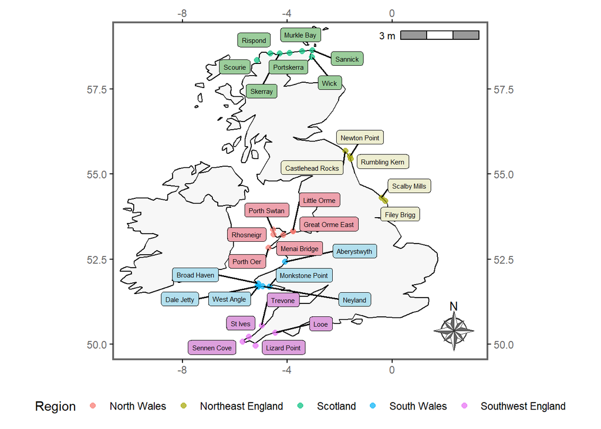

```r
site_map <- ggplot() +
  geom_polygon(data = worldUk,
               aes(x = long, y = lat, group = group),
               fill = 'grey97', color = 'black') +
  coord_fixed(ratio = 1.3, xlim = c(-10, 3), ylim = c(50, 59)) +
  theme_classic() +
  scale_x_continuous(sec.axis = dup_axis()) +
  scale_y_continuous(sec.axis = dup_axis()) +
  geom_point(data = unique_data,
             aes(x = as.numeric(decimalLongitude),
                 y = as.numeric(decimalLatitude),
                 color = country),
             size = 2, alpha = .7) +  # Adjusted size for better visibility
  geom_label_repel(data = unique_data,
                   aes(x = as.numeric(decimalLongitude),
                       y = as.numeric(decimalLatitude),
                       label = verbatimLocality,
                       fill = country),  # Using 'verbatimLocality' as the label
                   size = 2,
                   segment.size = 0.7,  # Adjust segment size
                   box.padding = 0.3,  # Adjust padding around labels
                   label.size = 0.25,
                   max.overlaps = 100) +  # Border size of the label
  scale_fill_manual(values = country_colors, guide = "none") +  # Apply custom colors and remove fill legend
  scale_color_discrete(name = "Region") +  # Changed legend name to 'Region'
  theme(legend.position = "bottom",
        axis.title = element_blank(),
        axis.line = element_line(colour = "grey40",
                                 linewidth = 0.8),
        axis.text = element_text(colour = "grey40")) +
  ggspatial::annotation_north_arrow(
    location = "br", which_north = "true",
    #pad_x = unit(0.4, "in"), pad_y = unit(0.4, "in"),
    style = ggspatial::north_arrow_nautical(
      fill = c("grey40", "white"),
      line_col = "grey20",
      text_family = "ArcherPro Book"
    )
  ) +
  ggspatial::annotation_scale(
    location = "tr",
    bar_cols = c("grey60", "white"),
    text_family = "ArcherPro Book"
  )

ggsave(filename = "Figures/site_map_chpt2.png", plot = site_map,
       device = "png", dpi = 300, units = "mm", height = 180, width = 190)

site_map
```

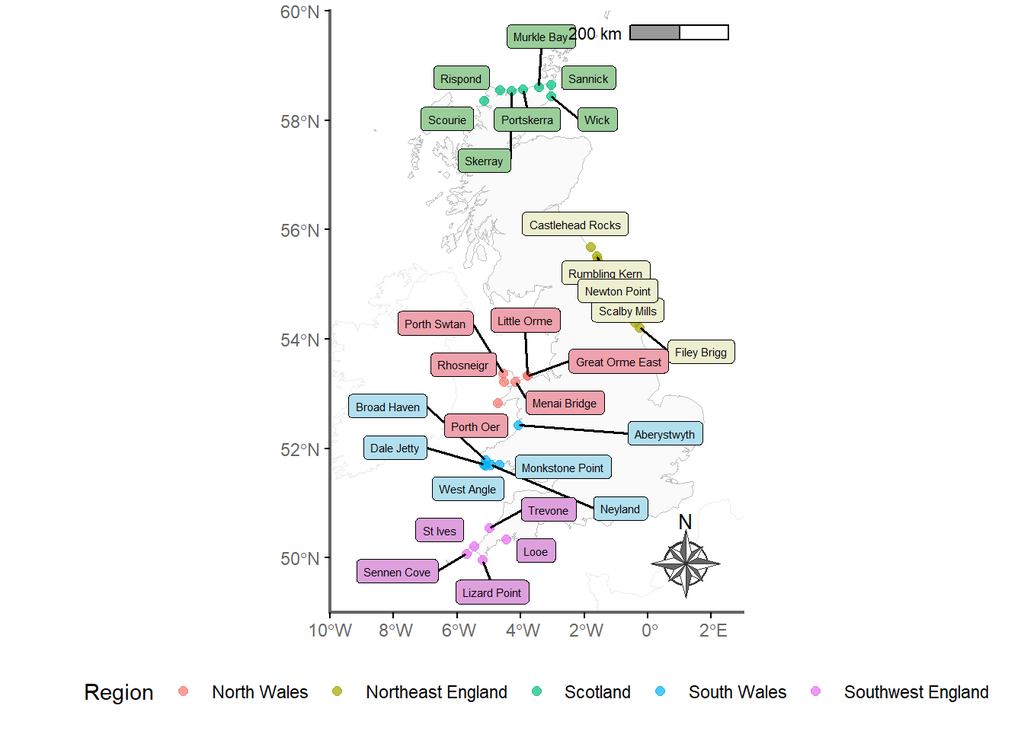

```r
# Get UK boundaries at admin level 1 (countries/subunits)
uk <- rnaturalearth::ne_countries(country = c("United Kingdom"), returnclass = "sf", scale = "large")

northern_ireland <- rnaturalearth::ne_states(country = "United Kingdom", returnclass = "sf") %>%
  filter(geonunit == "Northern Ireland")   %>%
  st_union() %>%      # merge all the small pieces
  st_as_sf()          # back to sf object

other_maps <- rnaturalearth::ne_countries(country = c("Ireland", "Isle of Man", "France"), returnclass = "sf", scale = "large")

# Base ggplot map
map <- ggplot() +
  geom_sf(data = uk, fill = "grey98", color = "grey") +
  geom_sf(data = other_maps, fill = "white", color = "grey92") +
  geom_sf(data = northern_ireland, fill = "white", color = "grey92") +
  coord_sf(
  xlim = c(-10, 3),
  ylim = c(49, 60),
  expand = FALSE
) +
  theme_classic() +
  scale_x_continuous(sec.axis = dup_axis()) +
  scale_y_continuous(sec.axis = dup_axis()) +
  geom_point(data = unique_data,
             aes(x = as.numeric(decimalLongitude),
                 y = as.numeric(decimalLatitude),
                 color = country),
             size = 2, alpha = .7) +  # Adjusted size for better visibility
  geom_label_repel(data = unique_data,
                   aes(x = as.numeric(decimalLongitude),
                       y = as.numeric(decimalLatitude),
                       label = verbatimLocality,
                       fill = country),  # Using 'verbatimLocality' as the label
                   size = 2,
                   segment.size = 0.7,  # Adjust segment size
                   box.padding = 0.3,  # Adjust padding around labels
                   label.size = 0.25,
                   max.overlaps = 100) +  # Border size of the label
  scale_fill_manual(values = country_colors, guide = "none") +  # Apply custom colors and remove fill legend
  scale_color_discrete(name = "Region") +  # Changed legend name to 'Region'
  theme(legend.position = "bottom",
        axis.title = element_blank(),
        axis.line = element_line(colour = "grey40",
                                 linewidth = 0.8),
        axis.text = element_text(colour = "grey40")) +
  ggspatial::annotation_north_arrow(
    location = "br", which_north = "true",
    #pad_x = unit(0.4, "in"), pad_y = unit(0.4, "in"),
    style = ggspatial::north_arrow_nautical(
      fill = c("grey40", "white"),
      line_col = "grey20",
      text_family = "ArcherPro Book"
    )
  ) +
  ggspatial::annotation_scale(
    location = "tr",
    bar_cols = c("grey60", "white"),
    text_family = "ArcherPro Book"
  )

map
```

```r
ggsave(filename = "Figures/site_map_chpt2_updated.png", plot = map,
       device = "png", dpi = 300, units = "mm", height = 200, width = 170)
```

## Visualize eDNA detections

First, set some variables for plots.

```r
site_order <- c(
  "Scourie",
  "Rispond",
  "Skerray",
  "Murkle Bay",
  "Portskerra",
  #"Borwick, Yesnaby",
  "Sannick",
  "Wick", #Scotland
  "Great Orme East",
  "Little Orme",
  "Menai Bridge",
  "Porth Oer",
  "Porth Swtan",
  "Rhosneigr", #North Wales
  "Castlehead Rocks",
  "Filey Brigg",
  "Newton Point",
  "Rumbling Kern",
  "Scalby Mills", #Northumbria
  "Aberystwyth",
  "Neyland",
  "Broad Haven",
  #"Skomer Island",
  "West Angle",
  "Monkstone Point",
  "Dale Jetty",
  #"Martin's Haven", #South Wales
  "Lizard Point",
  "Looe",
  "Sennen Cove",
  "St Ives",
  "Trevone" #Cornwall
)

country_order <- as.factor(c(
  "Scotland",
  "Northeast England",
  "North Wales",
  "South Wales",
  "Southwest England"
))

colours = c(
  "Scotland" = "darkseagreen1",
  "North Wales" = "lightpink",
  "Northeast England" = "lightyellow",
  "South Wales" = "lightblue1",
  "Southwest England" = "lavender"
)
```

Let’s look at the number of reads of each MarClim species across regions. These will be saved into the figure folder within the project.

```r
plot_list <- list()
grid_index <- 1

for (i in seq_along(visual_genera)) {
  genus_name <- visual_genera[i]
  tryCatch({
    taxa <- subset_taxa(phylo_rocky_eDNA, genus == genus_name)

    if (sum(phyloseq::otu_table(taxa)) == 0) {
      stop(paste("No taxa found for genus:", genus_name))
    }

    p <- plot_bar(taxa, x = "country", fill = "valid_name") +
      labs(y = "Read count", x = "Region",
           colour = paste0("Taxa within ", genus_name),
           fill = paste0("Taxa within ", genus_name)) +
      theme_classic() +
      scale_x_discrete(limits = country_order) +
      theme(plot.title = element_text(hjust = 0, size = 10),
            axis.text.x = element_text(angle = 45, hjust = 1)) +
      geom_bar(aes(color = valid_name, fill = valid_name), stat = "identity", position = "stack")

    individual_path <- paste0("Figures/Marclim_Regions/", genus_name, "_regions.png")
    ggsave(filename = individual_path, plot = p, width = 11, height = 9, dpi = 300)

    plot_list[[length(plot_list) + 1]] <- p

    if (length(plot_list) == 10) {
      grid_plot <- plot_grid(
  plotlist = plot_list,
  ncol = 2,
  nrow = 5,
  align = "hv",
  labels = letters[1:length(plot_list)]
)

      grid_path <- paste0("Figures/Marclim_Regions/Grid_", grid_index, ".png")
      ggsave(filename = grid_path, plot = grid_plot, width = 14, height = 18, dpi = 300)

      plot_list <- list()
      grid_index <- grid_index + 1
    }

  }, error = function(e) {
    message(paste("Error with genus:", genus_name, " - ", e$message))
  })
}

# loop after the loop: Save remaining plots if any
if (length(plot_list) > 0) {
  grid_plot <- plot_grid(plotlist = plot_list, ncol = 2, nrow = 1, align = "hv", labels = letters[1:length(plot_list)])
  grid_path <- paste0("Figures/Marclim_Regions/Grid_", grid_index, ".png")
  ggsave(filename = grid_path, plot = grid_plot, width = 14, height = 5, dpi = 300)
}
```

```r
plot_list <- list()
grid_index <- 1  # Track the grid number

for (i in seq_along(visual_genera)) {
  genus_name <- visual_genera[i]

  tryCatch({
    # Filter the long-format data for the current genus
    taxa <- eDNA %>% dplyr::filter(genus == genus_name)

    # Check if data is present
    if (nrow(taxa) == 0) {
      stop(paste("No taxa found for genus:", genus_name))
    }

    # Create the bar plot using ggplot
    p <- ggplot(taxa, aes(x = country, y = reads, fill = valid_name)) +
      geom_bar(stat = "identity", position = "stack") +
      labs(
        y = "Read count",
        x = "Shore Height",
        fill = "Valid name",
        title = paste0("Taxa within ", genus_name)
      ) +
      theme_classic() +
      theme(
        plot.title = element_text(hjust = 0, size = 10),
        axis.text.x = element_text(angle = 45, hjust = 1)
      )

    # Save individual plot
    individual_path <- paste0("Figures/Marclim_Regions_long/", genus_name, "_regions.png")
    ggsave(filename = individual_path, plot = p, width = 11, height = 9, dpi = 300)

    # Add plot to list
    plot_list[[length(plot_list) + 1]] <- p

    # Save grid when we have 12 plots, or on final loop
    if (length(plot_list) == 12 || i == length(visual_genera)) {
      grid_plot <- plot_grid(plotlist = plot_list, ncol = 2, nrow = 6, align = "hv")
      grid_path <- paste0("Figures/Marclim_Regions_long/Grid_", grid_index, ".png")
      ggsave(filename = grid_path, plot = grid_plot, width = 14, height = 20, dpi = 300)

      plot_list <- list()  # Reset
      grid_index <- grid_index + 1
    }

  }, error = function(e) {
    message(paste("Error with genus:", genus_name, " - ", e$message))
  })
}
```

## Detection concordance from paired sampling

### Bubble plots

We want to visualize our detection across sites and phyla.

Species-level bubble plot.

```r
# remove those note detected throughout the whole dataset
combined_data_matched <- combined_data %>%
  #filter(!genus == taxa) %>% # use this to remove codium and mytilus
  dplyr::group_by(taxa) %>%
  filter(sum(pa) > 0) %>%    # Keep only taxa with at least one pa == 1
  ungroup()

# correct order for region
combined_data_matched$region <- factor(combined_data_matched$region,
                                       levels = c("Scotland",
                                                  "Northeast England",
                                                  "North Wales",
                                                  "South Wales",
                                                  "Southwest England"))

# check min and max of count
visual_data_check <- subset(combined_data_matched, method == "Visual" & count > 0)
min(visual_data_check$count)
```

```
[1] 0.30103
```

```r
max(visual_data_check$count)
```

```
[1] 8.005625
```

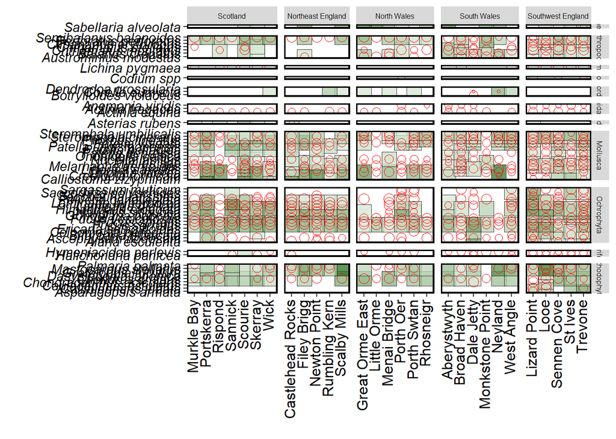

```r
# Plot
comp_bubble_species <- ggplot(combined_data_matched, aes(x = site, y = taxa)) +
  # eDNA detections (size and fill mapped to prop_samples_found)
  geom_point(aes(
    size = if_else(method == "eDNA" & pa == 1, 3, NA_real_),
    fill = if_else(method == "eDNA" & pa == 1, prop_samples_found, NA_real_)
  ),
  alpha = 0.75,
  shape = 22) +

  # Visual detections (size applied, but using color instead of fill)
  geom_point(aes(
    size = if_else(method == "Visual" & pa == 1, count/8, NA_real_),
    color = if_else(method == "Visual" & pa == 1, "red", NA_character_)
  ), shape = 21) +

  # Labels
  labs(x = "",
       y = "",
       size = "",
       fill = "Proportion of samples with positive detection") +

  # Theme settings
  theme(
    legend.key = element_blank(),
    axis.text.x = element_text(
      colour = "black",
      size = 12,
      angle = 90,
      vjust = 0.3,
      hjust = 1
    ),
    axis.text.y = element_text(
      colour = "black",
      size = 11,
      face = "italic"
    ),
    legend.text = element_text(size = 10, colour = "black"),
    legend.title = element_text(size = 10),
    panel.background = element_blank(),
    panel.border = element_rect(
      colour = "black",
      fill = NA,
      size = 1.2
    ),
    legend.position = "none",
    strip.text.y = element_text(size = 6),
    strip.text.x = element_text(size = 6)
  ) +

  # Use a continuous fill scale for eDNA values
  scale_fill_gradient(
    low = "honeydew2",
    high = "darkgreen",
    na.value = "grey",
    limits = c(0,1)
  ) +

  # Use a manual color scale for visual detections
  scale_color_manual(values = c("red" = "red"), na.translate = FALSE) +

  # Faceting
  facet_grid(phylum ~ region, scales = "free", space = "free")

comp_bubble_species
```

Genus-level bubble plot.

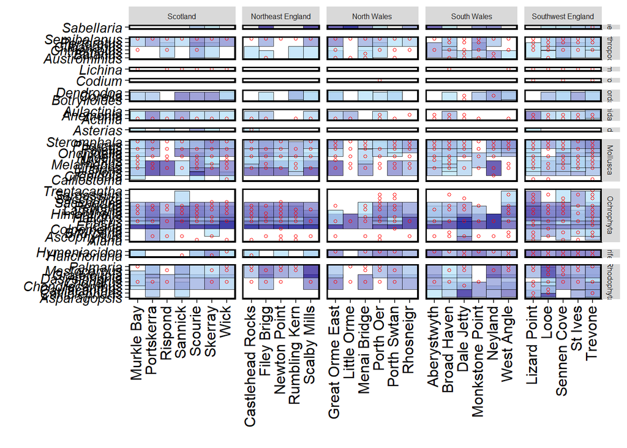

```r
# remove taxa without any detections across the dataset
combined_data_genus <- combined_data_genus %>%
  dplyr::group_by(genus) %>%
  filter(sum(pa) > 0) %>%    # Keep only taxa with at least one pa == 1
  ungroup()

combined_data_genus$region <- factor(combined_data_genus$region,
                                       levels = c("Scotland",
                                                  "Northeast England",
                                                  "North Wales",
                                                  "South Wales",
                                                  "Southwest England"))

# Plot
comp_bubble_genus <- ggplot(combined_data_genus, aes(x = site, y = genus)) +
  # eDNA detections (size and fill mapped to prop_samples_found)
  geom_point(aes(
    size = if_else(method == "eDNA" & pa == 1, 3, NA_real_),
    fill = if_else(method == "eDNA" & pa == 1, prop_samples_found, NA_real_)
  ),
  alpha = 0.75,
  shape = 22) +

  # Visual detections (size applied, but using color instead of fill)
  geom_point(aes(
    size = if_else(method == "Visual" & pa == 1, 1, NA_real_),
    color = if_else(method == "Visual" & pa == 1, "red", NA_character_)
  ), shape = 21) +

  # Labels
  labs(x = "",
       y = "",
       size = "",
       fill = "Proportion of samples with positive detection") +

  # Theme settings
  theme(
    legend.key = element_blank(),
    axis.text.x = element_text(
      colour = "black",
      size = 12,
      angle = 90,
      vjust = 0.3,
      hjust = 1
    ),
    axis.text.y = element_text(
      colour = "black",
      size = 11,
      face = "italic"
    ),
    legend.text = element_text(size = 10, colour = "black"),
    legend.title = element_text(size = 10),
    panel.background = element_blank(),
    panel.border = element_rect(
      colour = "black",
      fill = NA,
      size = 1.2
    ),
    legend.position = "none",
    strip.text.y = element_text(size = 6),
    strip.text.x = element_text(size = 6)
  ) +

  # Use a continuous fill scale for eDNA values
scale_fill_gradient(
  low = "lightblue1",
  high = "darkblue",
  na.value = "grey",
  limits = c(0, 1)
) +

  # Use a manual color scale for visual detections
  scale_color_manual(values = c("red" = "red"), na.translate = FALSE) +

  # Faceting
  facet_grid(phylum ~ region, scales = "free", space = "free")

comp_bubble_genus
```

Family-level bubble plot.

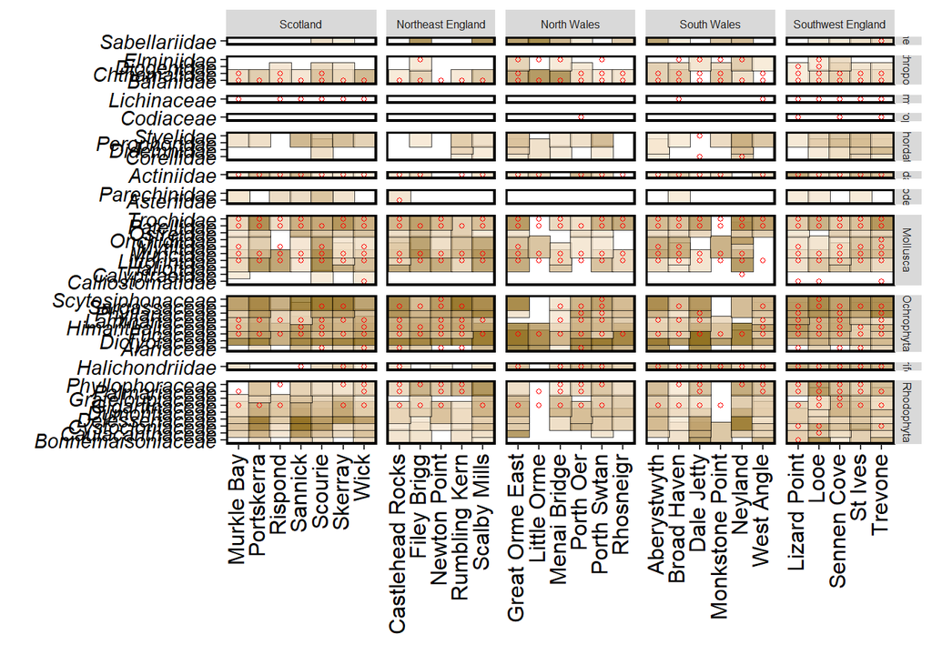

```r
# remove taxa without any detections across the dataset
combined_data_family <- combined_data_family %>%
  dplyr::group_by(family) %>%
  filter(sum(pa) > 0) %>%    # Keep only taxa with at least one pa == 1
  ungroup()

combined_data_family$region <- factor(combined_data_family$region,
                                       levels = c("Scotland",
                                                  "Northeast England",
                                                  "North Wales",
                                                  "South Wales",
                                                  "Southwest England"))

# Plot
comp_bubble_family <- ggplot(combined_data_family, aes(x = site, y = family)) +
  # eDNA detections (size and fill mapped to prop_samples_found)
  geom_point(aes(
    size = if_else(method == "eDNA" & pa == 1, 3, NA_real_),
    fill = if_else(method == "eDNA" & pa == 1, prop_samples_found, NA_real_)
  ),
  alpha = 0.75,
  shape = 22) +

  # Visual detections (size applied, but using color instead of fill)
  geom_point(aes(
    size = if_else(method == "Visual" & pa == 1, 1, NA_real_),
    color = if_else(method == "Visual" & pa == 1, "red", NA_character_)
  ), shape = 21) +

  # Labels
  labs(x = "",
       y = "",
       size = "",
       fill = "Proportion of samples with positive detection") +

  # Theme settings
  theme(
    legend.key = element_blank(),
    axis.text.x = element_text(
      colour = "black",
      size = 12,
      angle = 90,
      vjust = 0.3,
      hjust = 1
    ),
    axis.text.y = element_text(
      colour = "black",
      size = 11,
      face = "italic"
    ),
    legend.text = element_text(size = 10, colour = "black"),
    legend.title = element_text(size = 10),
    panel.background = element_blank(),
    panel.border = element_rect(
      colour = "black",
      fill = NA,
      size = 1.2
    ),
    legend.position = "none",
    strip.text.y = element_text(size = 6),
    strip.text.x = element_text(size = 6)
  ) +

  # Use a continuous fill scale for eDNA values
  scale_fill_gradient(
    low = "antiquewhite",
    high = "goldenrod4",
    na.value = "grey",
  limits = c(0, 1)
  ) +

  # Use a manual color scale for visual detections
  scale_color_manual(values = c("red" = "red"), na.translate = FALSE) +

  # Faceting
  facet_grid(phylum ~ region, scales = "free", space = "free")

comp_bubble_family
```

### Save bubble plots

```r
ggsave(filename = "Figures/comparison_bubble_species.png",
       plot = comp_bubble_species, device = "png", dpi = 300, units = "mm", height = 320, width = 200)

ggsave(filename = "Figures/comparison_bubble_genus.png",
       plot = comp_bubble_genus, device = "png", dpi = 300, units = "mm", height = 300, width = 180)

ggsave(filename = "Figures/comparison_bubble_family.png",
       plot = comp_bubble_family, device = "png", dpi = 300, units = "mm", height = 260, width = 180)
```

### Concordance table

We want to know the percentage match between the two methods across the sites. This is also done across species, genus and family.

```r
percentage_match <- combined_data %>%
  select(-count) %>%
  filter(pa == 1) %>%
  unique() %>%
  dplyr::group_by(taxa, region) %>%
  dplyr::summarise(
    eDNA_detected = sum(method == "eDNA"),
    # Count of eDNA detections for each taxa
    visual_detected = sum(method == "Visual"),
    # Count of visual detections for each taxa
    total_detected = eDNA_detected + visual_detected,
    # Total detections
    perc_match = ifelse(total_detected > 0, (eDNA_detected / total_detected) * 100, 0),
    # Calculate percentage match
    more_detected = case_when(
      eDNA_detected > visual_detected ~ "eDNA",
      visual_detected > eDNA_detected ~ "Visual",
      TRUE ~ "Equal"  # In case of a tie
    )
  ) %>%
  dplyr::ungroup()

percentage_match
```

```
# A tibble: 206 × 7
   taxa           region eDNA_detected visual_detected total_detected perc_match
   <chr>          <chr>          <int>           <int>          <int>      <dbl>
 1 Actinia equina North…             0               4              4          0
 2 Actinia equina North…             0               4              4          0
 3 Actinia equina Scotl…             0               7              7          0
 4 Actinia equina South…             0               5              5          0
 5 Actinia equina South…             0               5              5          0
 6 Actinia fraga… South…             0               1              1          0
 7 Alaria escule… North…             0               1              1          0
 8 Alaria escule… North…             0               3              3          0
 9 Alaria escule… Scotl…             0               2              2          0
10 Alaria escule… South…             0               3              3          0
# ℹ 196 more rows
# ℹ 1 more variable: more_detected <chr>
```

```r
# save as CSV
write.csv(percentage_match, file = "Processed_Data/percentage_match_species.csv", row.names = FALSE)

# not over regions
percentage_match_no_region <- combined_data %>%
  select(-count) %>%
  filter(pa == 1) %>%
  unique() %>%
  dplyr::group_by(taxa) %>%
  dplyr::summarise(
    eDNA_detected = sum(method == "eDNA"),
    # Count of eDNA detections for each taxa
    visual_detected = sum(method == "Visual"),
    # Count of visual detections for each taxa
    total_detected = eDNA_detected + visual_detected,
    # Total detections
    perc_match = ifelse(total_detected > 0, (eDNA_detected / total_detected) * 100, 0),
    # Calculate percentage match
    more_detected = case_when(
      eDNA_detected > visual_detected ~ "eDNA",
      visual_detected > eDNA_detected ~ "Visual",
      TRUE ~ "Equal"  # In case of a tie
    )
  ) %>%
  dplyr::ungroup()

# save as CSV
write.csv(percentage_match_no_region, file = "Processed_Data/percentage_match_species_no_region.csv", row.names = FALSE)
```

```r
percentage_match_genus <- combined_data_genus %>%
  select(-count) %>%
  filter(pa == 1) %>%
  unique() %>%
  dplyr::group_by(genus, region) %>%
  dplyr::summarise(
    eDNA_detected = sum(method == "eDNA"),
    # Count of eDNA detections for each taxa
    visual_detected = sum(method == "Visual"),
    # Count of visual detections for each taxa
    total_detected = eDNA_detected + visual_detected,
    # Total detections
    perc_match = ifelse(total_detected > 0, (eDNA_detected / total_detected) * 100, 0),
    # Calculate percentage match
    more_detected = case_when(
      eDNA_detected > visual_detected ~ "eDNA",
      visual_detected > eDNA_detected ~ "Visual",
      TRUE ~ "Equal"  # In case of a tie
    )
  ) %>%
  dplyr::ungroup()

print(percentage_match_genus)
```

```
# A tibble: 182 × 7
   genus    region       eDNA_detected visual_detected total_detected perc_match
   <chr>    <fct>                <int>           <int>          <int>      <dbl>
 1 Actinia  Scotland                 7               7             14       50
 2 Actinia  Northeast E…             3               4              7       42.9
 3 Actinia  North Wales              3               4              7       42.9
 4 Actinia  South Wales              1               5              6       16.7
 5 Actinia  Southwest E…             5               5             10       50
 6 Alaria   Scotland                 0               2              2        0
 7 Alaria   Northeast E…             0               3              3        0
 8 Alaria   North Wales              0               1              1        0
 9 Alaria   Southwest E…             0               3              3        0
10 Anemonia North Wales              0               2              2        0
# ℹ 172 more rows
# ℹ 1 more variable: more_detected <chr>
```

```r
# save as CSV
write.csv(percentage_match_genus, file = "Processed_Data/percentage_match_genus.csv", row.names = FALSE)

# not over regions
percentage_match_genus_no_region <- combined_data_genus %>%
  select(-count) %>%
  filter(pa == 1) %>%
  unique() %>%
  dplyr::group_by(genus) %>%
  dplyr::summarise(
    eDNA_detected = sum(method == "eDNA"),
    # Count of eDNA detections for each taxa
    visual_detected = sum(method == "Visual"),
    # Count of visual detections for each taxa
    total_detected = eDNA_detected + visual_detected,
    # Total detections
    perc_match = ifelse(total_detected > 0, (eDNA_detected / total_detected) * 100, 0),
    # Calculate percentage match
    more_detected = case_when(
      eDNA_detected > visual_detected ~ "eDNA",
      visual_detected > eDNA_detected ~ "Visual",
      TRUE ~ "Equal"  # In case of a tie
    )
  ) %>%
  dplyr::ungroup()

# save as CSV
write.csv(percentage_match_genus_no_region, file = "Processed_Data/percentage_match_genus_no_region.csv", row.names = FALSE)
```

```r
percentage_match_family <- combined_data_family %>%
  select(-count) %>%
  filter(pa == 1) %>%
  unique() %>%
  dplyr::group_by(family, region) %>%
  dplyr::summarise(
    eDNA_detected = sum(method == "eDNA"),
    # Count of eDNA detections for each taxa
    visual_detected = sum(method == "Visual"),
    # Count of visual detections for each taxa
    total_detected = eDNA_detected + visual_detected,
    # Total detections
    perc_match = ifelse(total_detected > 0, (eDNA_detected / total_detected) * 100, 0),
    # Calculate percentage match
    more_detected = case_when(
      eDNA_detected > visual_detected ~ "eDNA",
      visual_detected > eDNA_detected ~ "Visual",
      TRUE ~ "Equal"  # In case of a tie
    )
  ) %>%
  dplyr::ungroup()

print(percentage_match_family)
```

```
# A tibble: 164 × 7
   family     region     eDNA_detected visual_detected total_detected perc_match
   <chr>      <fct>              <int>           <int>          <int>      <dbl>
 1 Actiniidae Scotland               7               7             14       50
 2 Actiniidae Northeast…             3               4              7       42.9
 3 Actiniidae North Wal…             4               5              9       44.4
 4 Actiniidae South Wal…             5               5             10       50
 5 Actiniidae Southwest…             5               5             10       50
 6 Alariaceae Scotland               0               2              2        0
 7 Alariaceae Northeast…             0               3              3        0
 8 Alariaceae North Wal…             0               1              1        0
 9 Alariaceae Southwest…             0               3              3        0
10 Asteriidae Scotland               5               0              5      100
# ℹ 154 more rows
# ℹ 1 more variable: more_detected <chr>
```

```r
# save as CSV
write.csv(percentage_match_family, file = "Processed_Data/percentage_match_family.csv", row.names = FALSE)

# not over regions
percentage_match_family_no_region <- combined_data_family %>%
  select(-count) %>%
  filter(pa == 1) %>%
  unique() %>%
  dplyr::group_by(family) %>%
  dplyr::summarise(
    eDNA_detected = sum(method == "eDNA"),
    # Count of eDNA detections for each taxa
    visual_detected = sum(method == "Visual"),
    # Count of visual detections for each taxa
    total_detected = eDNA_detected + visual_detected,
    # Total detections
    perc_match = ifelse(total_detected > 0, (eDNA_detected / total_detected) * 100, 0),
    # Calculate percentage match
    more_detected = case_when(
      eDNA_detected > visual_detected ~ "eDNA",
      visual_detected > eDNA_detected ~ "Visual",
      TRUE ~ "Equal"  # In case of a tie
    )
  ) %>%
  dplyr::ungroup()

# save as CSV
write.csv(percentage_match_family_no_region, file = "Processed_Data/percentage_match_family_no_region.csv", row.names = FALSE)
```

## Diversity

### Alpha diversity

Time to do our alpha diversity visualizations and analyses.

#### Calculate richness

Let’s calculate richness at each taxonomic level for direct and indirect comparisons.

Indirect first.

```r
# phyloseq
alpha_df_visual <- phyloseq::estimate_richness(physeq = phylo_MarClim, measure = c("Observed", "Shannon"))

alpha_df_eDNA <- phyloseq::estimate_richness(physeq = phylo_rocky_eDNA_marlcim_species, measure = c("Observed", "Shannon"))

# long
diversity_data <- combined_data %>%
  dplyr::group_by(region, method, site) %>%
  dplyr::summarize(
    richness = sum(pa),
    rank = "Species"
  ) %>%
  na.omit()%>%
  mutate(method_rank = paste(rank, method, sep = "_"))

head(diversity_data)
```

```
# A tibble: 6 × 6
# Groups:   region, method [1]
  region      method site            richness rank    method_rank
  <chr>       <chr>  <chr>              <dbl> <chr>   <chr>
1 North Wales Visual Great Orme East       19 Species Species_Visual
2 North Wales Visual Little Orme           13 Species Species_Visual
3 North Wales Visual Menai Bridge          21 Species Species_Visual
4 North Wales Visual Porth Oer             26 Species Species_Visual
5 North Wales Visual Porth Swtan           25 Species Species_Visual
6 North Wales Visual Rhosneigr             14 Species Species_Visual
```

```r
# phyloseq
alpha_df_eDNA_genus <- phyloseq::estimate_richness(physeq = phylo_rocky_eDNA_marlcim_genus, measure = c("Observed", "Shannon"))

# long
diversity_data_genus <- combined_data_genus %>%
  dplyr::group_by(region, method, site) %>%
  dplyr::summarize(
    richness = sum(num_taxa_unique),
    rank = "Genus"
  ) %>%
  na.omit()%>%
  mutate(method_rank = paste(rank, method, sep = "_"))

head(diversity_data_genus)
```

```
# A tibble: 6 × 6
# Groups:   region, method [1]
  region   method site       richness rank  method_rank
  <fct>    <chr>  <chr>         <int> <chr> <chr>
1 Scotland Visual Murkle Bay       20 Genus Genus_Visual
2 Scotland Visual Portskerra       18 Genus Genus_Visual
3 Scotland Visual Rispond          19 Genus Genus_Visual
4 Scotland Visual Sannick          17 Genus Genus_Visual
5 Scotland Visual Scourie          20 Genus Genus_Visual
6 Scotland Visual Skerray          22 Genus Genus_Visual
```

```r
alpha_df_eDNA_family <- phyloseq::estimate_richness(physeq = phylo_rocky_eDNA_marlcim_family, measure = c("Observed", "Shannon"))

diversity_data_family <- combined_data_family %>%
  dplyr::group_by(region, method, site) %>%
  dplyr::summarize(
    richness = sum(num_taxa_unique),
    rank = "Family") %>%
  na.omit() %>%
  mutate(method_rank = paste(rank, method, sep = "_"))

head(diversity_data_family)
```

```
# A tibble: 6 × 6
# Groups:   region, method [1]
  region   method site       richness rank   method_rank
  <fct>    <chr>  <chr>         <int> <chr>  <chr>
1 Scotland Visual Murkle Bay       20 Family Family_Visual
2 Scotland Visual Portskerra       18 Family Family_Visual
3 Scotland Visual Rispond          19 Family Family_Visual
4 Scotland Visual Sannick          17 Family Family_Visual
5 Scotland Visual Scourie          20 Family Family_Visual
6 Scotland Visual Skerray          22 Family Family_Visual
```

Phylum level

```r
alpha_df_eDNA_phylum <- phyloseq::estimate_richness(physeq = phylo_rocky_eDNA_marlcim_phylum, measure = c("Observed", "Shannon"))

diversity_data_phylum <- combined_data_phylum %>%
  dplyr::group_by(region, method, site) %>%
  dplyr::summarize(
    richness = sum(num_taxa_unique),
    rank = "Phylum") %>%
  na.omit() %>%
  mutate(method_rank = paste(rank, method, sep = "_"))

head(diversity_data_phylum)
```

```
# A tibble: 6 × 6
# Groups:   region, method [1]
  region      method site            richness rank   method_rank
  <chr>       <chr>  <chr>              <int> <chr>  <chr>
1 North Wales Visual Great Orme East       19 Phylum Phylum_Visual
2 North Wales Visual Little Orme           13 Phylum Phylum_Visual
3 North Wales Visual Menai Bridge          21 Phylum Phylum_Visual
4 North Wales Visual Porth Oer             26 Phylum Phylum_Visual
5 North Wales Visual Porth Swtan           25 Phylum Phylum_Visual
6 North Wales Visual Rhosneigr             14 Phylum Phylum_Visual
```

```r
diversity_overall <- rbind(diversity_data_genus, diversity_data_family, diversity_data_phylum) # genus, family and phylum

#diversity_overall <- diversity_overall %>%
  #subset(!method_rank %in% c("Family_Visual", "Genus_Visual"))
```

And let’s calculate difference in richness between the two methods for plots and models later.

```r
# Duplicate Visual data for Genus and Family
#visual_expanded <- diversity_overall %>%
  #filter(method == "Visual") %>%
  #mutate(rank = "Genus") %>%
  #bind_rows(
    #diversity_overall %>% filter(method == "Visual") %>% mutate(rank = "Family")
  #)

#ranks <- c("Species", "Genus", "Family", "Phylum")
#diversity_overall_expanded <- bind_rows(diversity_overall, visual_expanded) %>%
  #filter(rank %in% ranks)  # Ensure only selected ranks

# make wide for scatter and cal difference
diversity_indirect_diff <- diversity_overall %>%
  select(site, rank, method, richness, region) %>%
  pivot_wider(names_from = method, values_from = richness) %>%
  mutate(richness_diff =Visual - `eDNA`)

diversity_indirect_diff$region = as.factor(diversity_indirect_diff$region)
diversity_indirect_diff$rank = as.factor(diversity_indirect_diff$rank)
diversity_indirect_diff$site = as.factor(diversity_indirect_diff$site)

# Reorder region factor levels
diversity_indirect_diff$region <- factor(diversity_indirect_diff$region, levels = country_order)
```

```r
# means
summary_indirect_raw <- diversity_overall %>%
  group_by(method, rank) %>%
  summarise(
    mean = mean(richness, na.rm = TRUE),
    sd = sd(richness, na.rm = TRUE),
    n = sum(!is.na(richness)),  # count of non-NA observations
    se = sd / sqrt(n),
    .groups = "drop"
  )

summary_indirect_raw
```

```
# A tibble: 6 × 6
  method rank    mean    sd     n    se
  <chr>  <chr>  <dbl> <dbl> <int> <dbl>
1 Visual Family  23.3  7.67    29  1.42
2 Visual Genus   23.3  7.67    29  1.42
3 Visual Phylum  23.3  7.67    29  1.42
4 eDNA   Family  34.7 11.3     29  2.09
5 eDNA   Genus   20.2  6.36    29  1.18
6 eDNA   Phylum 182.  60.6     29 11.3
```

Direct next (using the agglomerated data).

```r
# species - visual
visual_aglom_rich_sp <- phyloseq::estimate_richness(physeq = phylo_MarClim_aglom_sp, measure = "Observed")
visual_aglom_rich_sp$tax_rank = "Species"
visual_aglom_rich_sp$method = "Visual"
visual_aglom_rich_sp <- rownames_to_column(visual_aglom_rich_sp, var = "site")

# genus - visual
visual_aglom_rich_genus <- phyloseq::estimate_richness(physeq = phylo_MarClim_aglom_genus, measure = "Observed")
visual_aglom_rich_genus$tax_rank = "Genus"
visual_aglom_rich_genus$method = "Visual"
visual_aglom_rich_genus <- rownames_to_column(visual_aglom_rich_genus, var = "site")

# family - visual
visual_aglom_rich_family <- phyloseq::estimate_richness(physeq = phylo_MarClim_aglom_family, measure = "Observed")
visual_aglom_rich_family$tax_rank = "Family"
visual_aglom_rich_family$method = "Visual"
visual_aglom_rich_family <- rownames_to_column(visual_aglom_rich_family, var = "site")

# species - eDNA
eDNA_aglom_rich_sp <- phyloseq::estimate_richness(physeq = phylo_rocky_eDNA_aglom_sp, measure = "Observed")
eDNA_aglom_rich_sp$tax_rank = "Species"
eDNA_aglom_rich_sp$method = "eDNA"
eDNA_aglom_rich_sp <- rownames_to_column(eDNA_aglom_rich_sp, var = "site")

# genus - eDNA
eDNA_aglom_rich_genus <- phyloseq::estimate_richness(physeq = phylo_rocky_eDNA_aglom_genus, measure = "Observed")
eDNA_aglom_rich_genus$tax_rank = "Genus"
eDNA_aglom_rich_genus$method = "eDNA"
eDNA_aglom_rich_genus <- rownames_to_column(eDNA_aglom_rich_genus, var = "site")

# family - eDNA
eDNA_aglom_rich_family <- phyloseq::estimate_richness(physeq = phylo_rocky_eDNA_aglom_family, measure = "Observed")
eDNA_aglom_rich_family$tax_rank = "Family"
eDNA_aglom_rich_family$method = "eDNA"
eDNA_aglom_rich_family <- rownames_to_column(eDNA_aglom_rich_family, var = "site")

# format to join together
diversity_agglom <- rbind(visual_aglom_rich_sp, visual_aglom_rich_genus, visual_aglom_rich_family, eDNA_aglom_rich_sp, eDNA_aglom_rich_genus, eDNA_aglom_rich_family)

# add region back in
metadata <- sample_data(phylo_MarClim_aglom_sp)
colnames(metadata)[1] <- "site"
diversity_agglom <- left_join(diversity_agglom, metadata)
```

```r
# means
summary_direct_raw <- diversity_agglom %>%
  group_by(tax_rank, method) %>%
  summarise(
    mean = mean(Observed, na.rm = TRUE),
    sd = sd(Observed, na.rm = TRUE),
    n = sum(!is.na(Observed)),  # count of non-NA observations
    se = sd / sqrt(n),
    .groups = "drop"
  )

summary_direct_raw
```

```
# A tibble: 6 × 6
  tax_rank method  mean    sd     n    se
  <chr>    <chr>  <dbl> <dbl> <int> <dbl>
1 Family   Visual  14.2  4.19    29 0.778
2 Family   eDNA    19.1  4.83    29 0.897
3 Genus    Visual  18.3  6.45    29 1.20
4 Genus    eDNA    15.2  4.91    29 0.911
5 Species  Visual  23.3  7.68    29 1.43
6 Species  eDNA    11.7  4.21    29 0.782
```

Now let’s calculate the difference in richness.

```r
# make wide for simple box plots
diversity_agglom_diff <- diversity_agglom %>%
  pivot_wider(names_from = method, values_from = Observed) %>%
  mutate(diff_Observed = Visual - eDNA)

# Reorder region factor levels
diversity_agglom_diff$country <- factor(diversity_agglom_diff$country, levels = country_order)
```

#### Models

Direct richness model first.

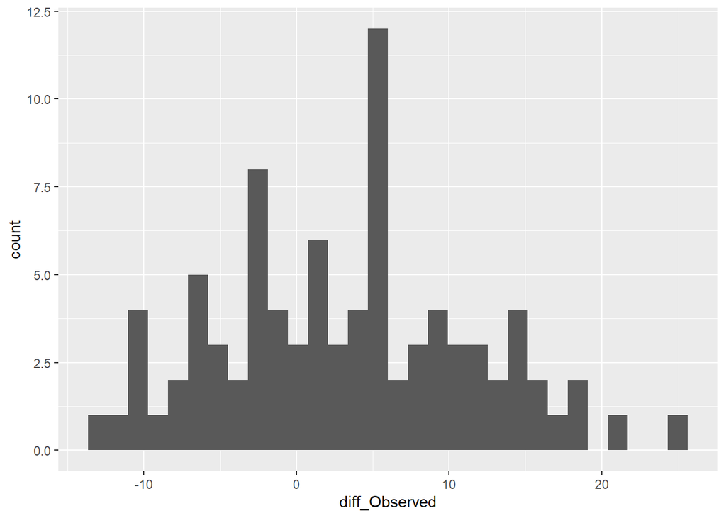

```r
# visualise
ggplot(diversity_agglom_diff, aes(x=diff_Observed)) + geom_histogram()
```

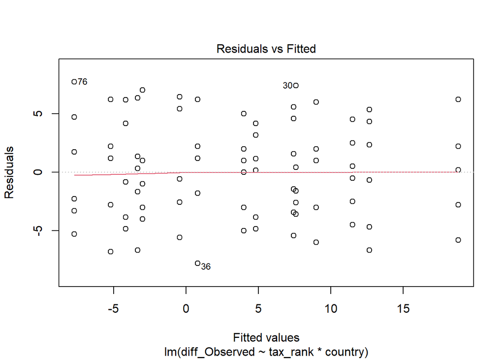

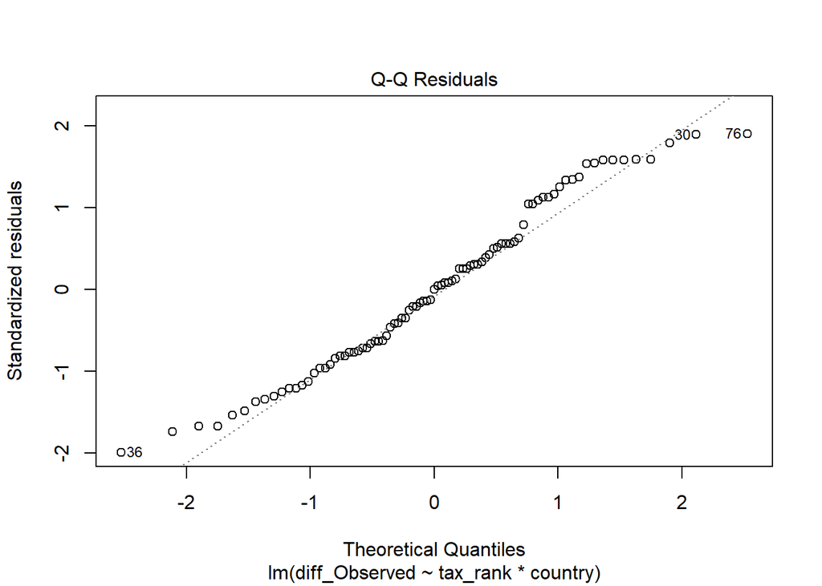

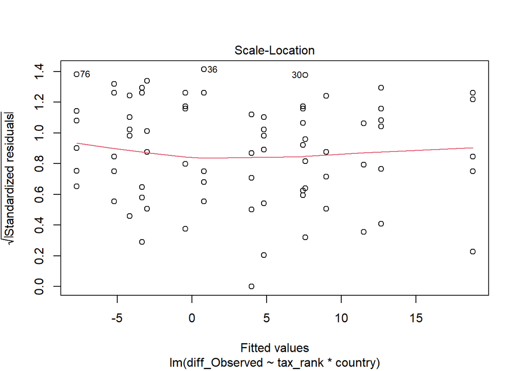

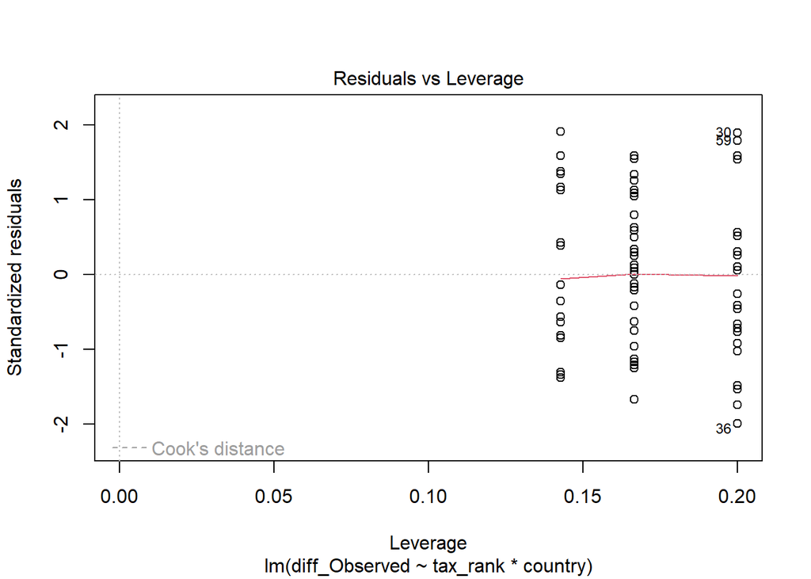

```r
# construct model
richess_dirct_mod <- lm(
  diff_Observed ~ tax_rank * country,
  data = diversity_agglom_diff
)

# checks
plot(richess_dirct_mod) #fine
```

```r
# outputs
summary(richess_dirct_mod)
```

```
Call:
lm(formula = diff_Observed ~ tax_rank * country, data = diversity_agglom_diff)

Residuals:
   Min     1Q Median     3Q    Max
-7.800 -3.000  0.000  2.417  7.714

Coefficients:
                                         Estimate Std. Error t value Pr(>|t|)
(Intercept)                               -7.7143     1.6513  -4.672 1.35e-05
tax_rankGenus                              7.2857     2.3353   3.120   0.0026
tax_rankSpecies                           15.1429     2.3353   6.484 9.72e-09
countryNortheast England                   2.5143     2.5582   0.983   0.3290
countryNorth Wales                         4.3810     2.4306   1.802   0.0757
countrySouth Wales                         3.5476     2.4306   1.460   0.1488
countrySouthwest England                   4.7143     2.5582   1.843   0.0695
tax_rankGenus:countryNortheast England    -1.2857     3.6178  -0.355   0.7233
tax_rankSpecies:countryNortheast England  -0.9429     3.6178  -0.261   0.7951
tax_rankGenus:countryNorth Wales           0.8810     3.4374   0.256   0.7985
tax_rankSpecies:countryNorth Wales        -0.3095     3.4374  -0.090   0.9285
tax_rankGenus:countrySouth Wales           0.8810     3.4374   0.256   0.7985
tax_rankSpecies:countrySouth Wales         1.6905     3.4374   0.492   0.6244
tax_rankGenus:countrySouthwest England     3.3143     3.6178   0.916   0.3627
tax_rankSpecies:countrySouthwest England   6.6571     3.6178   1.840   0.0699

(Intercept)                              ***
tax_rankGenus                            **
tax_rankSpecies                          ***
countryNortheast England
countryNorth Wales                       .
countrySouth Wales
countrySouthwest England                 .
tax_rankGenus:countryNortheast England
tax_rankSpecies:countryNortheast England
tax_rankGenus:countryNorth Wales
tax_rankSpecies:countryNorth Wales
tax_rankGenus:countrySouth Wales
tax_rankSpecies:countrySouth Wales
tax_rankGenus:countrySouthwest England
tax_rankSpecies:countrySouthwest England .
---
Signif. codes:  0 '***' 0.001 '**' 0.01 '*' 0.05 '.' 0.1 ' ' 1

Residual standard error: 4.369 on 72 degrees of freedom
Multiple R-squared:  0.7722,    Adjusted R-squared:  0.7279
F-statistic: 17.43 on 14 and 72 DF,  p-value: < 2.2e-16
```

```r
Anova(richess_dirct_mod, type = "II")
```

```
Anova Table (Type II tests)

Response: diff_Observed
                 Sum Sq Df  F value    Pr(>F)
tax_rank         3907.3  2 102.3533 < 2.2e-16 ***
country           646.2  4   8.4634  1.18e-05 ***
tax_rank:country  104.8  8   0.6866    0.7019
Residuals        1374.3 72
---
Signif. codes:  0 '***' 0.001 '**' 0.01 '*' 0.05 '.' 0.1 ' ' 1
```

```r
# means
summary_direct <- group_by(diversity_agglom_diff, tax_rank) %>%
  summarise(
    mean = mean(diff_Observed, na.rm = TRUE),
    sd = sd(diff_Observed, na.rm = TRUE)
  )

summary_direct
```

```
# A tibble: 3 × 3
  tax_rank  mean    sd
  <chr>    <dbl> <dbl>
1 Family   -4.83  4.59
2 Genus     3.17  4.89
3 Species  11.6   5.56
```

And indirect richness model.

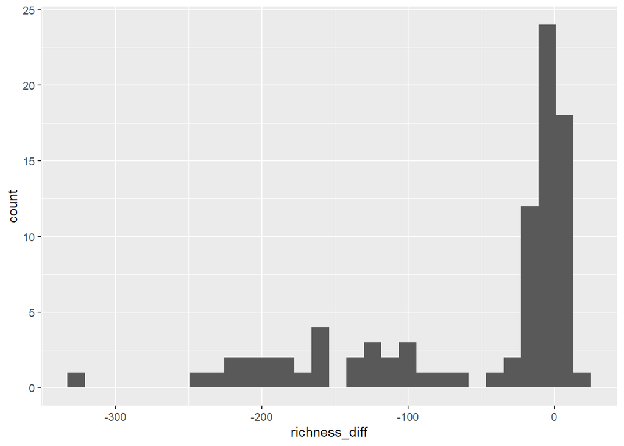

```r
# visualise
ggplot(diversity_indirect_diff, aes(x=richness_diff)) + geom_histogram()
```

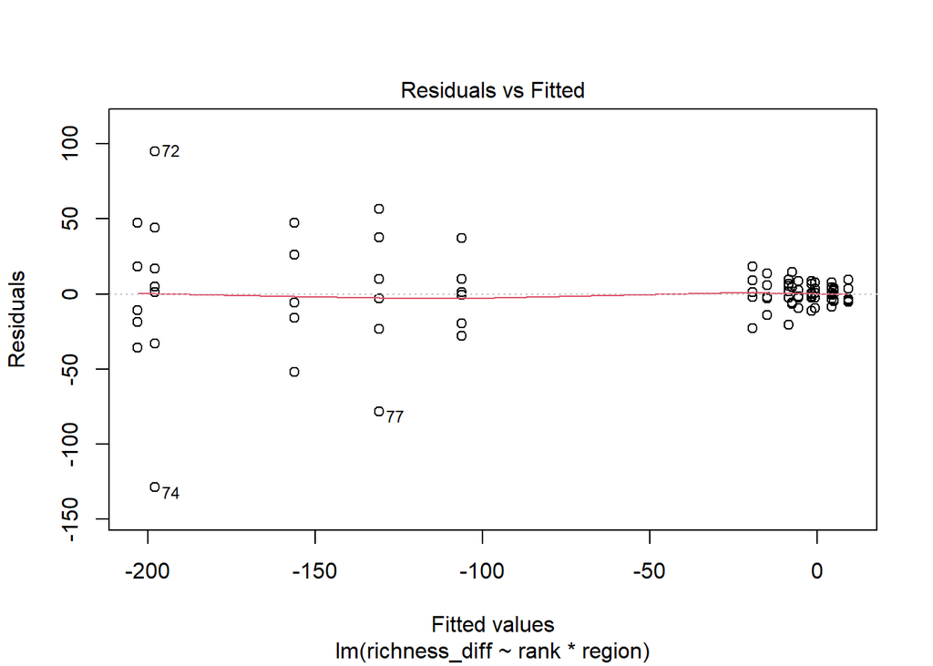

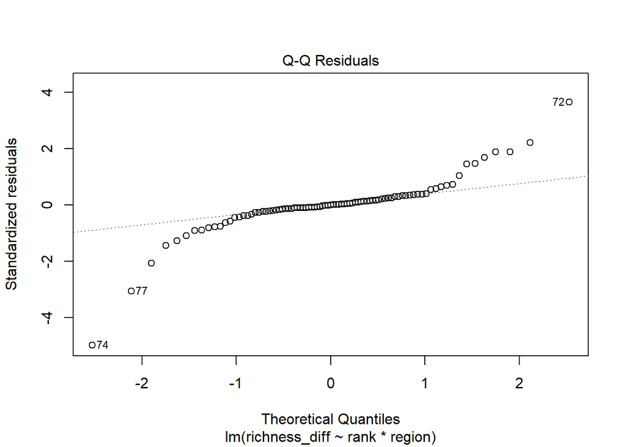

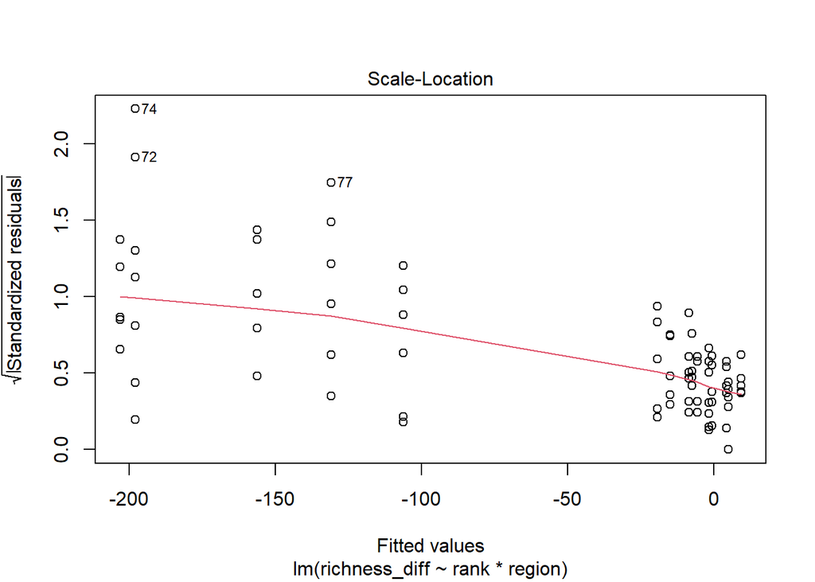

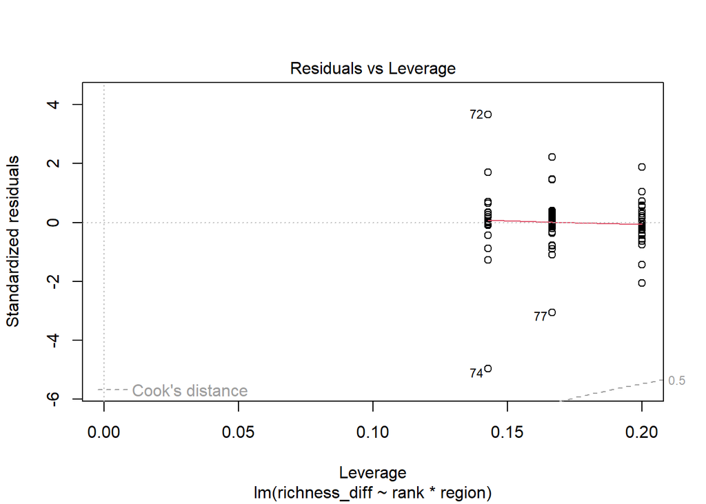

```r
# construct model
richess_indirct_mod <- lm(
  richness_diff ~ rank * region,
  data = diversity_indirect_diff
)

# checks
plot(richess_indirct_mod) #fine
```

```r
# outputs
summary(richess_indirct_mod)
```

```
Call:
lm(formula = richness_diff ~ rank * region, data = diversity_indirect_diff)

Residuals:
     Min       1Q   Median       3Q      Max
-129.000   -5.500    0.000    7.036   95.000

Coefficients:
                                    Estimate Std. Error t value Pr(>|t|)
(Intercept)                         -19.1429    10.5966  -1.807 0.075017 .
rankGenus                            17.5714    14.9858   1.173 0.244846
rankPhylum                         -178.8571    14.9858 -11.935  < 2e-16 ***
regionNortheast England               4.3429    16.4161   0.265 0.792113
regionNorth Wales                    13.6429    15.5977   0.875 0.384662
regionSouth Wales                    10.6429    15.5977   0.682 0.497217
regionSouthwest England              11.7429    16.4161   0.715 0.476722
rankGenus:regionNortheast England    -3.3714    23.2159  -0.145 0.884942
rankPhylum:regionNortheast England   37.4571    23.2159   1.613 0.111027
rankGenus:regionNorth Wales          -7.0714    22.0585  -0.321 0.749460
rankPhylum:regionNorth Wales         78.1905    22.0585   3.545 0.000695 ***
rankGenus:regionSouth Wales          -4.5714    22.0585  -0.207 0.836407
rankPhylum:regionSouth Wales         56.5238    22.0585   2.562 0.012485 *
rankGenus:regionSouthwest England    -0.7714    23.2159  -0.033 0.973584
rankPhylum:regionSouthwest England  -16.9429    23.2159  -0.730 0.467883
---
Signif. codes:  0 '***' 0.001 '**' 0.01 '*' 0.05 '.' 0.1 ' ' 1

Residual standard error: 28.04 on 72 degrees of freedom
Multiple R-squared:  0.8999,    Adjusted R-squared:  0.8804
F-statistic: 46.24 on 14 and 72 DF,  p-value: < 2.2e-16
```

```r
Anova(richess_indirct_mod, type = "II")
```

```
Anova Table (Type II tests)

Response: richness_diff
            Sum Sq Df  F value    Pr(>F)
rank        465549  2 296.1469 < 2.2e-16 ***
region       17574  4   5.5898 0.0005635 ***
rank:region  25657  8   4.0802 0.0004755 ***
Residuals    56593 72
---
Signif. codes:  0 '***' 0.001 '**' 0.01 '*' 0.05 '.' 0.1 ' ' 1
```

```r
# means
summary_indirect <- group_by(diversity_indirect_diff, rank) %>%
  summarise(
    mean = mean(richness_diff, na.rm = TRUE),
    sd = sd(richness_diff, na.rm = TRUE)
  )

summary_indirect
```

```
# A tibble: 3 × 3
  rank      mean    sd
  <fct>    <dbl> <dbl>
1 Family  -11.3  10.9
2 Genus     3.10  6.74
3 Phylum -159.   58.3
```

#### Plots

We are going to make a few different alpha plots using indirect and direct comparisons.

Indirect matches plots.

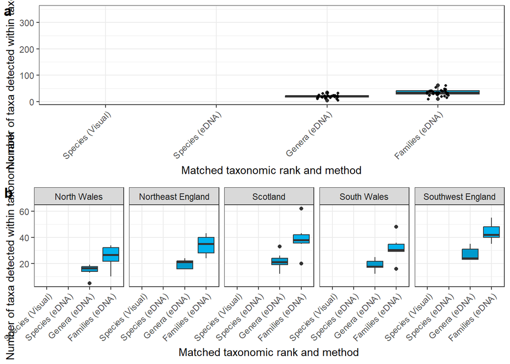

```r
rank_order <- c("Species_Visual", "Species_eDNA", "Genus_eDNA","Family_eDNA")

richness_comp_overall <- ggplot(diversity_overall,
                                aes(x = method_rank, y = richness, fill = method_rank)) +
  geom_boxplot() +
  scale_fill_manual(values = c(
    "Family_eDNA" = "deepskyblue2",
    "Genus_eDNA" = "deepskyblue3",
    "Species_eDNA" = "deepskyblue4",
    "Species_Visual" = "darkseagreen"
  )) +
  scale_x_discrete(labels = c(
    "Family_eDNA" = "Families (eDNA)",
    "Genus_eDNA" = "Genera (eDNA)",
    "Species_eDNA" = "Species (eDNA)",
    "Species_Visual" = "Species (Visual)"
  ), limits = rank_order) +
  geom_jitter(
    color = "black",
    size = 0.9,
    alpha = 0.9,
    width = 0.1,
    height = 0.1
  ) +
  labs(x = "Matched taxonomic rank and method", y = "Number of taxa detected within taxonomic rank") +
  theme_bw() +
  theme(axis.text.x = element_text(angle = 45, hjust = 1),
        legend.position = "none")

richness_comp_overall_region <- ggplot(diversity_overall,
                                aes(x = method_rank, y = richness, fill = method_rank)) +
  geom_boxplot() +
  scale_fill_manual(values = c(
    "Family_eDNA" = "deepskyblue2",
    "Genus_eDNA" = "deepskyblue3",
    "Species_eDNA" = "deepskyblue4",
    "Species_Visual" = "darkseagreen"
  )) +
  scale_x_discrete(labels = c(
    "Family_eDNA" = "Families (eDNA)",
    "Genus_eDNA" = "Genera (eDNA)",
    "Species_eDNA" = "Species (eDNA)",
    "Species_Visual" = "Species (Visual)"
  ), limits = rank_order) +
  labs(x = "Matched taxonomic rank and method", y = "Number of taxa detected within taxonomic rank") +
  theme_bw() +
  theme(axis.text.x = element_text(angle = 45, hjust = 1),
        legend.position = "none") +
  facet_wrap(~ region, ncol = 5)

alpha_diversity_overall_grid <- cowplot::plot_grid(richness_comp_overall, richness_comp_overall_region, labels = c("a", "b"), ncol = 1)

# save
ggsave(filename = "Figures/alpha_comp_plot_overall.png",
       plot = alpha_diversity_overall_grid, device = "png", dpi = 300, units = "mm", height = 250, width = 200)

alpha_diversity_overall_grid
```

Scatter plot to show difference in indirect richness across ranks.

```r
# mod
method_lm <- lm(eDNA ~ Visual * rank, diversity_indirect_diff)
summary(method_lm)
```

```
Call:
lm(formula = eDNA ~ Visual * rank, data = diversity_indirect_diff)

Residuals:
    Min      1Q  Median      3Q     Max
-76.160  -8.860  -1.000   6.669 174.339

Coefficients:
                  Estimate Std. Error t value Pr(>|t|)
(Intercept)        21.3912    20.5275   1.042  0.30048
Visual              0.5697     0.8368   0.681  0.49795
rankGenus         -11.8495    29.0303  -0.408  0.68422
rankPhylum         94.6070    29.0303   3.259  0.00164 **
Visual:rankGenus   -0.1113     1.1834  -0.094  0.92528
Visual:rankPhylum   2.2635     1.1834   1.913  0.05931 .
---
Signif. codes:  0 '***' 0.001 '**' 0.01 '*' 0.05 '.' 0.1 ' ' 1

Residual standard error: 33.97 on 81 degrees of freedom
Multiple R-squared:  0.8369,    Adjusted R-squared:  0.8268
F-statistic: 83.11 on 5 and 81 DF,  p-value: < 2.2e-16
```

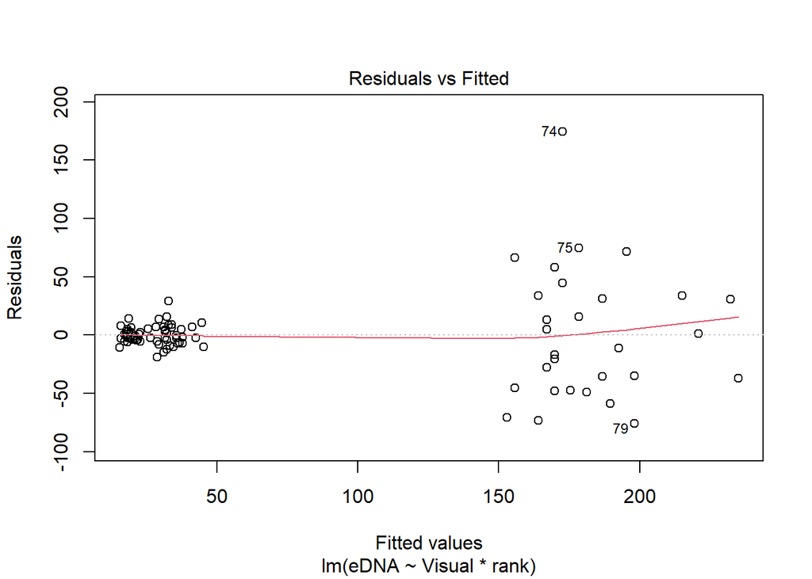

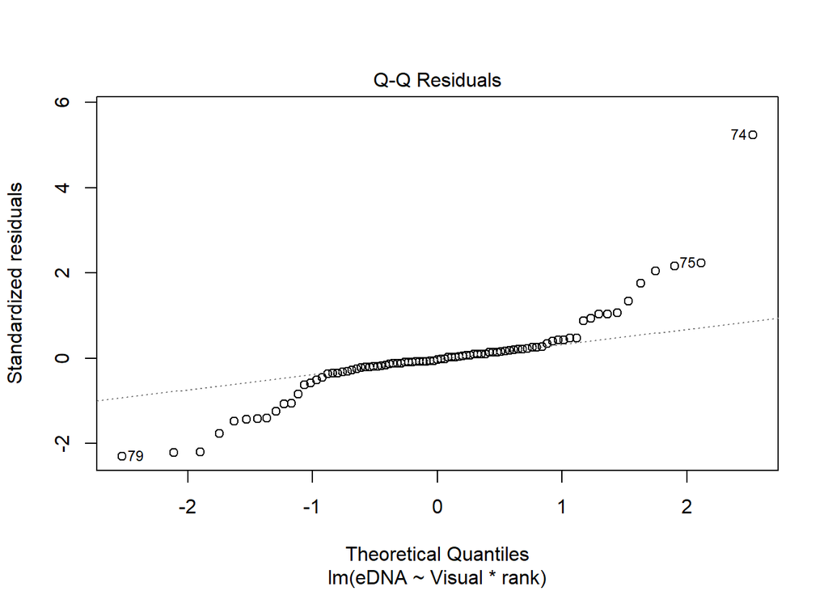

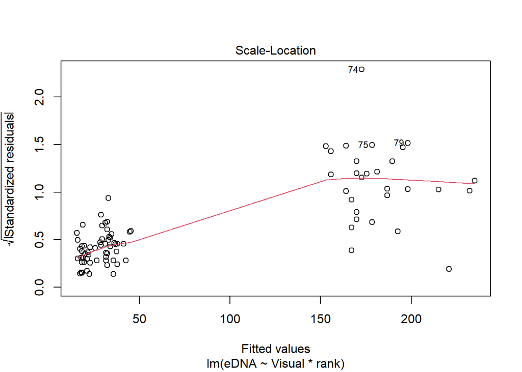

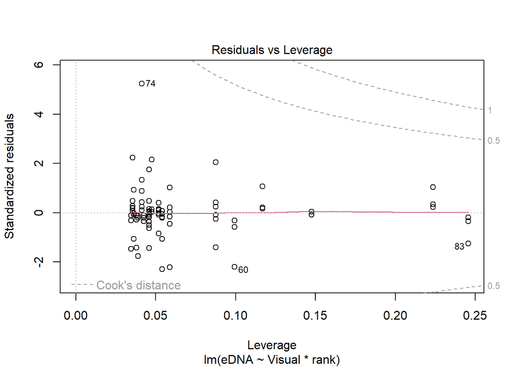

```r
plot(method_lm)
```

```r
anova(method_lm)
```

```
Analysis of Variance Table

Response: eDNA
            Df Sum Sq Mean Sq  F value    Pr(>F)
Visual       1   8192    8192   7.0976  0.009311 **
rank         2 465549  232774 201.6656 < 2.2e-16 ***
Visual:rank  2   5921    2961   2.5650  0.083152 .
Residuals   81  93495    1154
---
Signif. codes:  0 '***' 0.001 '**' 0.01 '*' 0.05 '.' 0.1 ' ' 1
```

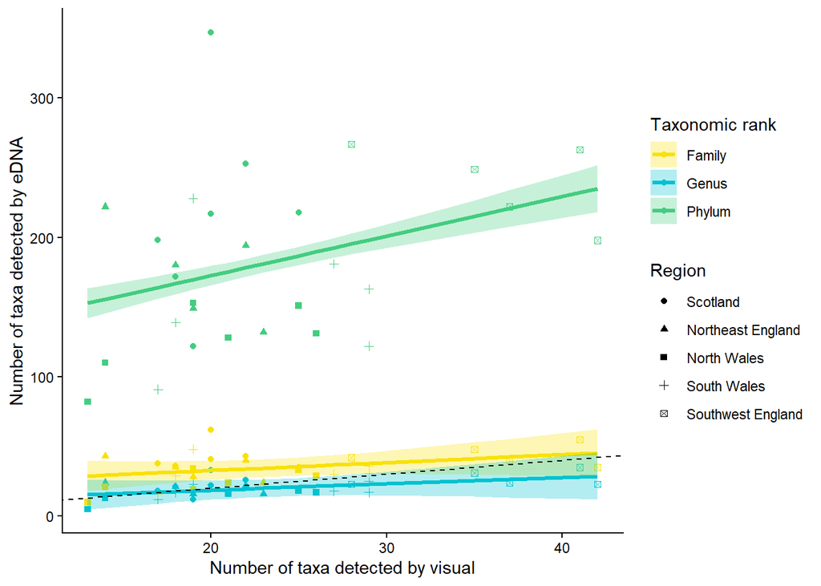

```r
# Extract the prediction data frame
pred.indirect <- ggeffects::ggpredict(method_lm, terms = c("Visual", "rank"))

# scatter
scatter_indirect <- ggplot(diversity_indirect_diff, aes(x = Visual, y = eDNA, colour = rank, shape = region)) +
  geom_point() +

  # Predicted lines (suppress global aes)
  geom_line(
    data = pred.indirect,
    aes(x = x, y = predicted, colour = group),
    linewidth = 1.2,
    inherit.aes = FALSE
  ) +

  # Confidence ribbon (suppress global aes)
  geom_ribbon(
    data = pred.indirect,
    aes(
      x = x,
      ymin = predicted - std.error,
      ymax = predicted + std.error,
      fill = group
    ),
    alpha = 0.3,
    inherit.aes = FALSE
  ) +

  geom_abline(intercept = 0, slope = 1, linetype = "dashed", colour = "black") +

  scale_colour_manual(values = c("Species" = "#F6AF65",
                                 "Genus" = "#00C2D1",
                                 "Family" = "#F9E108",
                                 "Phylum" = "seagreen3")) +
    scale_fill_manual(values = c("Species" = "#F6AF65",
                                 "Genus" = "#00C2D1",
                                 "Family" = "#F9E108",
                                 "Phylum" = "seagreen3")) +
  labs(colour = "Taxonomic rank",
       fill = "Taxonomic rank",
       x = "Number of taxa detected by visual",
       y = "Number of taxa detected by eDNA",
       shape = "Region") +
  theme_classic()

# save
ggsave(filename = "Figures/alpha_indirect_satter.png",
       plot = scatter_indirect, device = "png", dpi = 300, units = "mm", height = 120, width = 170)

scatter_indirect
```

Now let’s make the direct matches plot.

```r
diversity_agglom$tax_rank <- factor(diversity_agglom$tax_rank, levels = c("Species", "Genus", "Family"))

richness_comp_aglom <- ggplot(diversity_agglom, aes(x = country, y = Observed, fill = method)) +
  geom_boxplot() +
  labs(x = "Region", y = "Richness", pattern = "Survey method") +
  scale_fill_manual(values = c("eDNA" = "deepskyblue4",
                               "Visual" = "darkseagreen"))+
  theme_bw() +
  scale_x_discrete(limits = country_order) +
  theme(axis.text.x = element_text(angle = 45, hjust = 1),
        legend.position = "bottom") +
  labs(fill = "Method")+
  facet_grid(~ tax_rank)

richness_comp_overall_aglom <- ggplot(diversity_agglom, aes(x = method, y = Observed, fill = method)) +
  geom_boxplot()+
  #geom_line(aes(group=site), colour = "grey50") +
  scale_fill_manual(values = c("eDNA" = "deepskyblue4",
                               "Visual" = "darkseagreen"))+
  geom_jitter(color="black", size=0.9, alpha=0.9, width = 0.1, height = 0.1) +
  labs(x = "Method", y = "Richness") +
  theme_bw() +
  theme(axis.text.x = element_text(angle = 45, hjust = 1),
        legend.position = "none")+
  facet_grid(~ tax_rank)

#plot together
alpha_diversity_overall_grid_aglom <- cowplot::plot_grid(richness_comp_overall_aglom,richness_comp_aglom, labels = c("a", "b"), ncol = 1, rel_heights = c(1,1.2))
```

Save direct comparison plot.

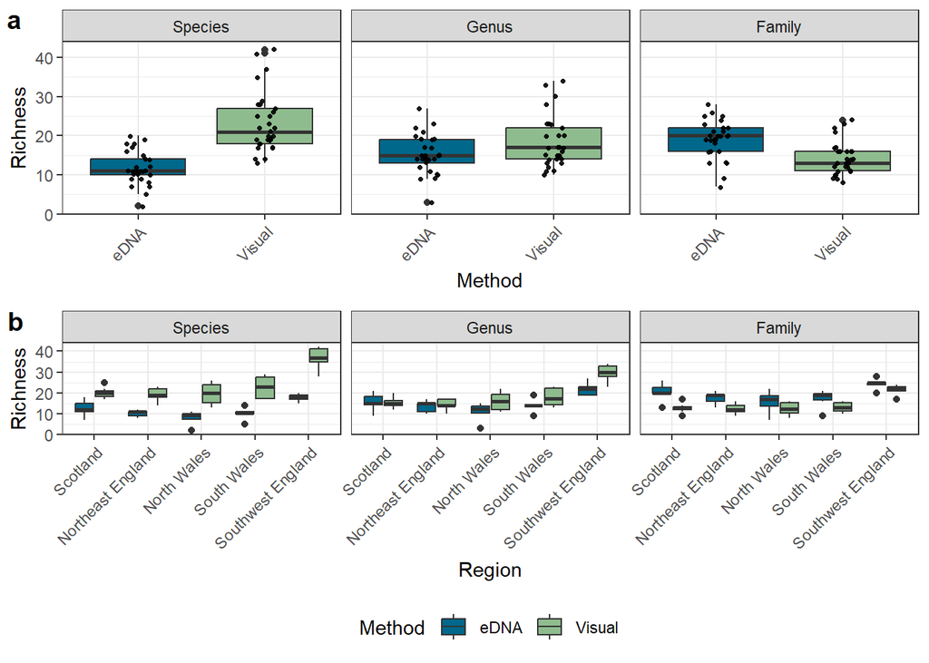

```r
ggsave(filename = "Figures/alpha_comp_plot_aglom.png",
       plot = alpha_diversity_overall_grid_aglom, device = "png", dpi = 300, units = "mm", height = 230, width = 200)

alpha_diversity_overall_grid_aglom
```

Plots for difference in richness.

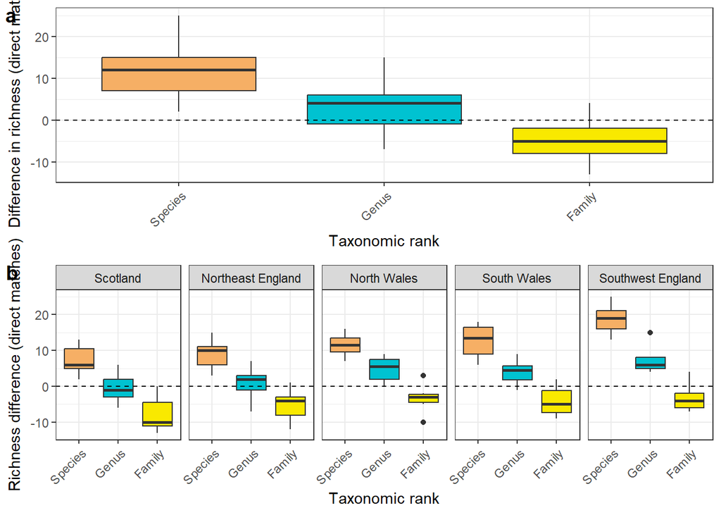

```r
tax_order <- c("Species", "Genus", "Family")

# Basic boxplot with dashed line at 0
simple_box_direct <- ggplot(diversity_agglom_diff, aes(x = tax_rank, y = diff_Observed, fill = tax_rank)) +
  geom_boxplot() +
  geom_hline(yintercept = 0, linetype = "dashed", color = "black") +
  labs(x = "Taxonomic rank", y = "Difference in richness (direct matches)") +
  scale_fill_manual(values = c("Species" = "#F6AF65",
                               "Genus" = "#00C2D1",
                               "Family" = "#F9E900")) +
  theme_bw() +
  scale_x_discrete(limits = tax_order) +
  theme(axis.text.x = element_text(angle = 45, hjust = 1),
        legend.position = "none") +
  labs(fill = "Taxonomic rank")

# Faceted boxplot with dashed line at 0
simple_box_direct_region <- ggplot(diversity_agglom_diff, aes(x = tax_rank, y = diff_Observed, fill = tax_rank)) +
  geom_boxplot() +
  geom_hline(yintercept = 0, linetype = "dashed", color = "black") +
  labs(x = "Taxonomic rank", y = "Richness difference (direct matches)") +
  scale_fill_manual(values = c("Species" = "#F6AF65",
                               "Genus" = "#00C2D1",
                               "Family" = "#F9E900")) +
  theme_bw() +
  scale_x_discrete(limits = tax_order) +
  theme(axis.text.x = element_text(angle = 45, hjust = 1),
        legend.position = "none") +
  labs(fill = "Taxonomic rank") +
  facet_wrap(~ country, ncol = 5)

# plot together
alpha_diversity_direct_diff <- cowplot::plot_grid(simple_box_direct,simple_box_direct_region, labels = c("a", "b"), ncol = 1)

ggsave(filename = "Figures/alpha_comp_plot_aglom_diff.png",
       plot = alpha_diversity_direct_diff, device = "png", dpi = 300, units = "mm", height = 230, width = 170)

alpha_diversity_direct_diff
```

```r
tax_order2 <- c("Genus", "Family", "Phylum")

# Faceted boxplot with dashed line at 0
simple_box_indirect_region <- ggplot(diversity_indirect_diff, aes(x = rank, y = richness_diff, fill = rank)) +
  geom_boxplot() +
  geom_hline(yintercept = 0, linetype = "dashed", color = "black") +
  labs(x = "Taxonomic rank", y = "Richness difference (indirect matches)") +
  scale_fill_manual(values = c("Genus" = "#00C2D1",
                               "Family" = "#F9E900",
                               "Phylum" = "seagreen3")) +
  theme_bw() +
  scale_x_discrete(limits = tax_order2) +
  theme(axis.text.x = element_text(angle = 45, hjust = 1),
        legend.position = "none") +
  labs(fill = "Taxonomic rank") +
  facet_wrap(~ region, ncol = 5)
```

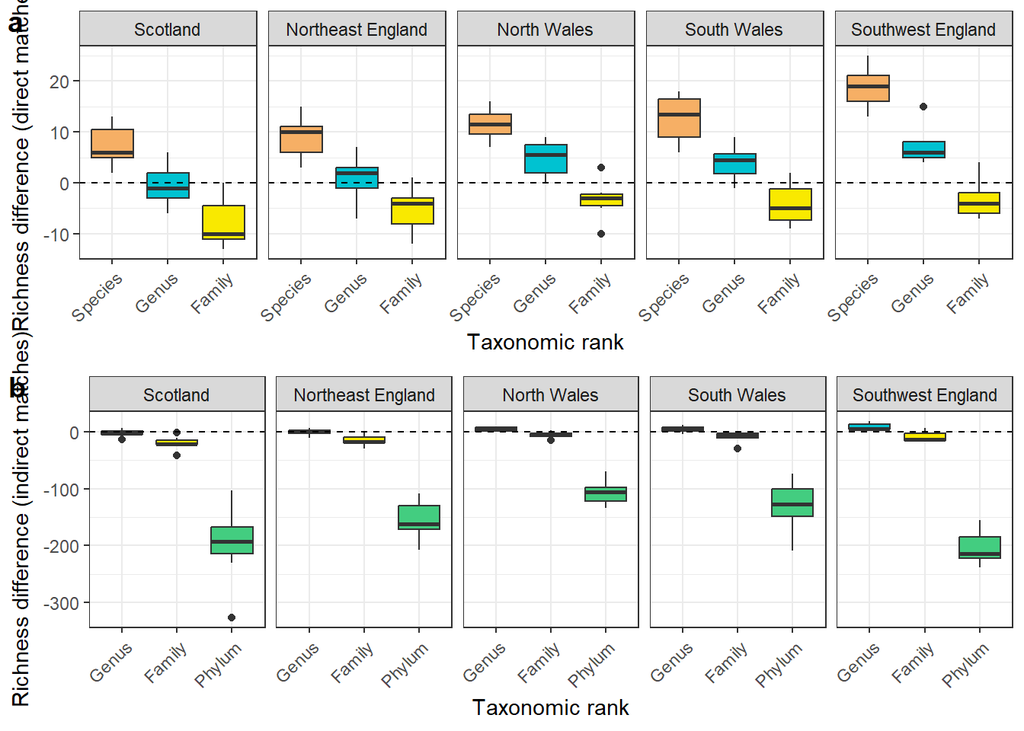

```r
# plot together
alpha_diversity_diff_together <- cowplot::plot_grid(simple_box_direct_region, simple_box_indirect_region, labels = c("a", "b"), ncol = 1)

ggsave(filename = "Figures/alpha_diff_direct_indirect.png",
       plot = alpha_diversity_diff_together, device = "png", dpi = 300, units = "mm", height = 230, width = 190)

alpha_diversity_diff_together
```

### Beta diversity

#### Composition plots

```r
# Compute relative abundance
df_rel <- direct_long_sp %>%
  group_by(region, method, phylum) %>%
  summarise(total_count = sum(count), .groups = "drop") %>%
  group_by(region, method) %>%
  mutate(rel_abundance = total_count / sum(total_count))

# Stacked bar plot
species_stacked <- ggplot(df_rel, aes(x = method, y = rel_abundance, fill = phylum)) +
  geom_bar(stat = "identity", position = "stack") +
  facet_wrap(~~factor(region, country_order), ncol = 5) +
  labs(x = "Method", y = "Relative Abundance", fill = "Phylum") +
  theme_classic() +
  theme(axis.text.x = element_text(angle = 45, hjust = 1),
        legend.position = "none",
        strip.text = element_text(size = 6))
```

```r
# Compute relative abundance
df_rel <- direct_long_genus %>%
  group_by(region, method, phylum) %>%
  summarise(total_count = sum(count), .groups = "drop") %>%
  group_by(region, method) %>%
  mutate(rel_abundance = total_count / sum(total_count))

# Stacked bar plot
genus_stacked <- ggplot(df_rel, aes(x = method, y = rel_abundance, fill = phylum)) +
  geom_bar(stat = "identity", position = "stack") +
  facet_wrap(~~factor(region, country_order), ncol = 5) +
  labs(x = "Method", y = "Relative Abundance", fill = "Phylum") +
  theme_classic() +
  theme(axis.text.x = element_text(angle = 45, hjust = 1),
        legend.position = "none",
        strip.text = element_text(size = 6))
```

```r
# Compute relative abundance
df_rel <- direct_long_family %>%
  group_by(region, method, phylum) %>%
  summarise(total_count = sum(count), .groups = "drop") %>%
  group_by(region, method) %>%
  mutate(rel_abundance = total_count / sum(total_count))

# Stacked bar plot
family_stacked <- ggplot(df_rel, aes(x = method, y = rel_abundance, fill = phylum)) +
  geom_bar(stat = "identity", position = "stack") +
  facet_wrap(~factor(region, country_order), ncol = 5) +
  labs(x = "Method", y = "Relative Abundance", fill = "Phylum") +
  theme_classic() +
  theme(axis.text.x = element_text(angle = 45, hjust = 1),
        legend.position = "none",
        strip.text = element_text(size = 6)
        )
```

```r
legend_plot_a <- ggplot(df_rel, aes(x = method, y = rel_abundance, fill = phylum)) +
  geom_bar(stat = "identity", position = "stack") +
  facet_wrap(~factor(region, country_order), ncol = 5) +
  labs(x = "Method", y = "Relative Abundance", fill = "Phylum") +
  theme_classic() +
  theme(axis.text.x = element_text(angle = 45, hjust = 1),
        legend.position = "bottom")

g_legend<-function(a.gplot){
  tmp <- ggplot_gtable(ggplot_build(a.gplot))
  leg <- which(sapply(tmp$grobs, function(x) x$name) == "guide-box")
  legend <- tmp$grobs[[leg]]
}

legend_a <- g_legend(legend_plot_a)
```

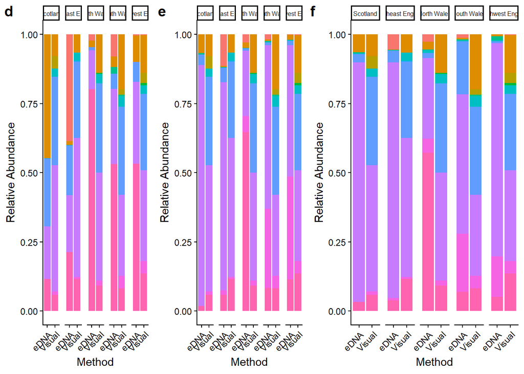

```r
stacked_comp_plot <- cowplot::plot_grid(species_stacked,
                                        genus_stacked,
                                        family_stacked,
                                        labels = c("d", "e", "f"),
                                        ncol = 3,
                                        rel_widths = c(1,1,1.4))

ggsave(filename = "Figures/all_stacked_composition.png",
       plot = stacked_comp_plot, device = "png", dpi = 300, units = "mm", height = 200, width = 400)

stacked_comp_plot
```

#### NMDS plots

Species-level

```r
ord.nmds.jaccard <- ordinate(phylo_direct_combined_sp, method = "NMDS", distance =
                                   "jaccard")
```

```
Square root transformation
Wisconsin double standardization
*** Best solution was not repeated -- monoMDS stopping criteria:
    17: stress ratio > sratmax
     3: scale factor of the gradient < sfgrmin
```

```r
stress_value_jaccard <- ord.nmds.jaccard$stress
```

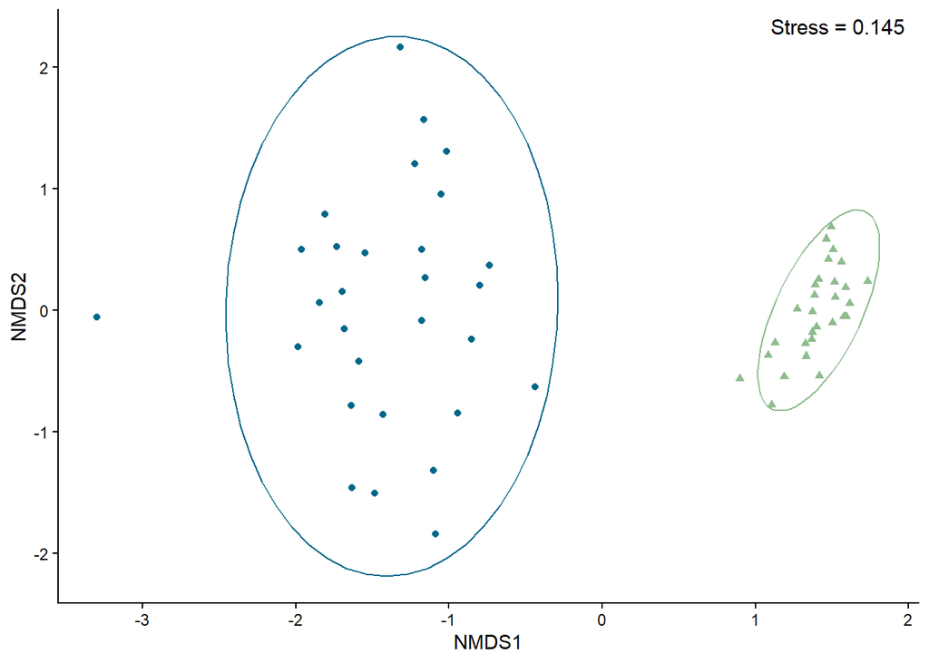

```r
NMDS_method_jaccard <- plot_ordination(phylo_direct_combined_sp, ord.nmds.jaccard, color="method", shape = "method")+
  theme_classic()+
  annotate("text", x = Inf, y = Inf, label = paste("Stress =", round(stress_value_jaccard, 3)),
           size = 4, hjust = 1.1, vjust = 1.5)+
  stat_ellipse(aes(group = method), type = "t", level = 0.95, linetype = 1, size = 0.5)+
  labs(color = "method", shape= "method") +
  theme(legend.position = "none") +
  #xlim(-1,1)+
  scale_color_manual(values = c("eDNA" = "deepskyblue4",
                                "Visual" = "darkseagreen"))+
  guides(colour = guide_legend(nrow = 2, byrow = TRUE))

NMDS_method_jaccard
```

Genus-level

```r
ord.nmds.jaccard.genus <- ordinate(phylo_direct_combined_genus, method = "NMDS", distance =
                                   "jaccard")
```

```
Square root transformation
Wisconsin double standardization
*** Best solution was not repeated -- monoMDS stopping criteria:
    18: stress ratio > sratmax
     2: scale factor of the gradient < sfgrmin
```

```r
stress_value_jaccard_genus <- ord.nmds.jaccard.genus$stress
```

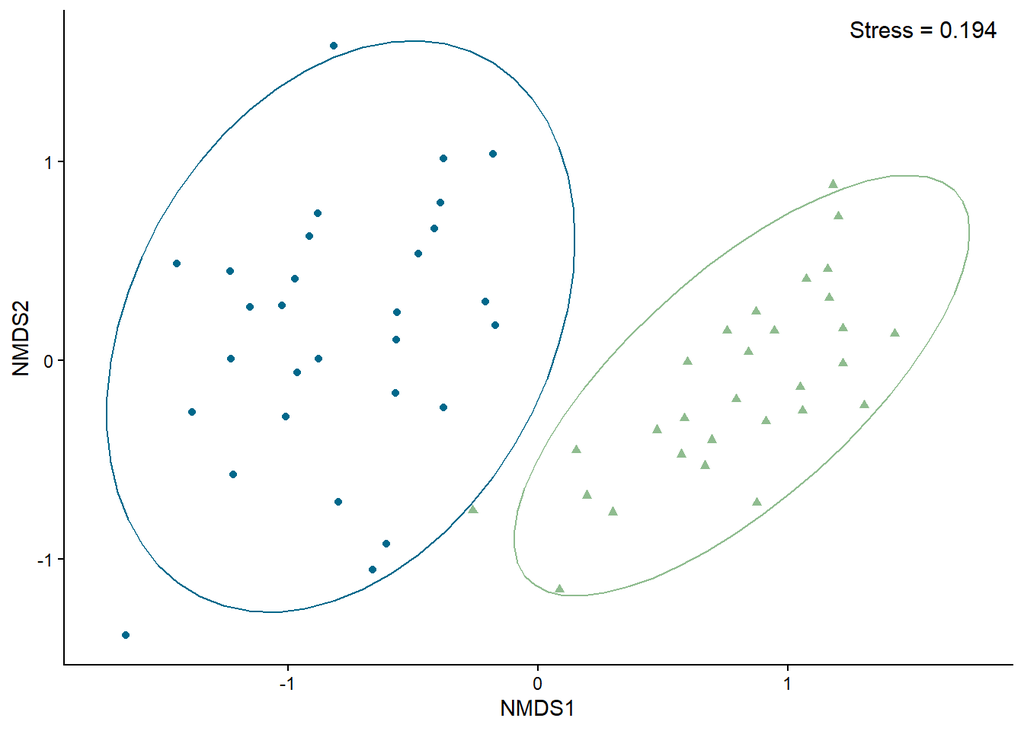

```r
NMDS_method_jaccard_genus <- plot_ordination(phylo_direct_combined_genus, ord.nmds.jaccard.genus, color="method",  shape = "method")+
  theme_classic()+
  annotate("text", x = Inf, y = Inf, label = paste("Stress =", round(stress_value_jaccard_genus, 3)),
           size = 4, hjust = 1.1, vjust = 1.5)+
  stat_ellipse(aes(group = method), type = "t", level = 0.95, linetype = 1, size = 0.5)+
  labs(color = "method") +
  scale_color_manual(values = c("eDNA" = "deepskyblue4", "Visual" = "darkseagreen"))+
  theme(legend.position = "none") +
  #xlim(-1,1)+
  guides(colour = guide_legend(nrow = 2, byrow = TRUE))

NMDS_method_jaccard_genus
```

Family-level

```r
ord.nmds.jaccard.family <- ordinate(phylo_direct_combined_family, method = "NMDS", distance =
                                   "jaccard")
```

```
Square root transformation
Wisconsin double standardization
*** Best solution was not repeated -- monoMDS stopping criteria:
    18: stress ratio > sratmax
     2: scale factor of the gradient < sfgrmin
```

```r
stress_value_jaccard_family <- ord.nmds.jaccard.family$stress
```

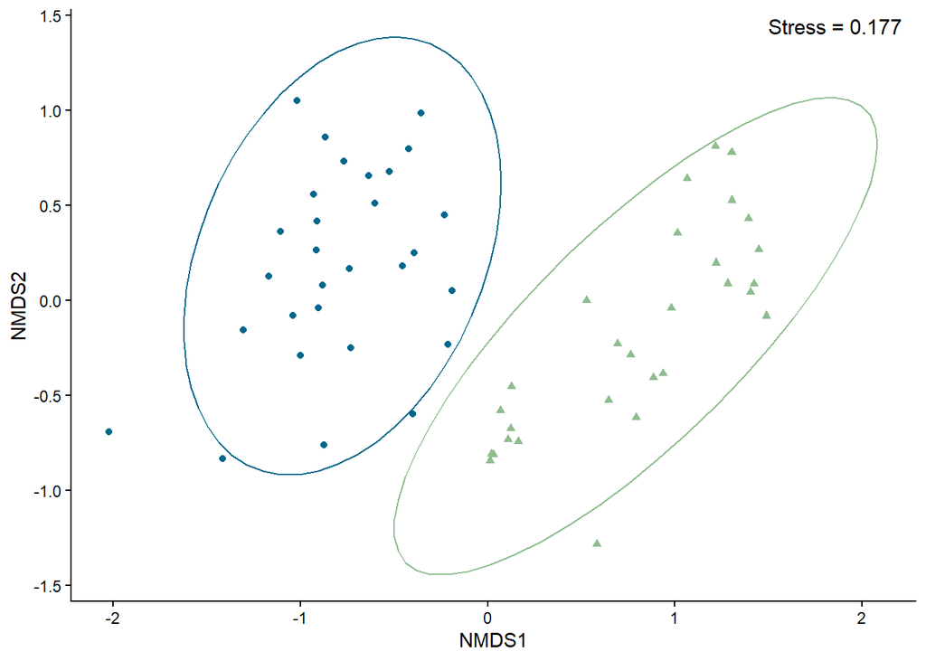

```r
NMDS_method_jaccard_family <- plot_ordination(phylo_direct_combined_family, ord.nmds.jaccard.family, color="method",  shape = "method")+
  theme_classic()+
  annotate("text", x = Inf, y = Inf, label = paste("Stress =", round(stress_value_jaccard_family, 3)),
           size = 4, hjust = 1.1, vjust = 1.5)+
  stat_ellipse(aes(group = method), type = "t", level = 0.95, linetype = 1, size = 0.5)+
  labs(color = "method") +
  theme(legend.position = "none") +
  scale_color_manual(values = c("eDNA" = "deepskyblue4", "Visual" = "darkseagreen"))+
  guides(colour = guide_legend(nrow = 2, byrow = TRUE))

NMDS_method_jaccard_family
```

```r
legend_plot_b <- plot_ordination(phylo_direct_combined_family, ord.nmds.jaccard.family, color="method",  shape = "method")+
  theme_classic()+
  annotate("text", x = Inf, y = Inf, label = paste("Stress =", round(stress_value_jaccard_family, 3)),
           size = 4, hjust = 1.1, vjust = 1.5)+
  stat_ellipse(aes(group = method), type = "t", level = 0.95, linetype = 1, size = 0.5)+
  labs(color = "Method", shape = "Method") +
  theme(legend.position = "bottom") +
  scale_color_manual(values = c("eDNA" = "deepskyblue4", "Visual" = "darkseagreen"))+
  guides(colour = guide_legend(nrow = 2, byrow = TRUE))

legend_b <- g_legend(legend_plot_b)
```

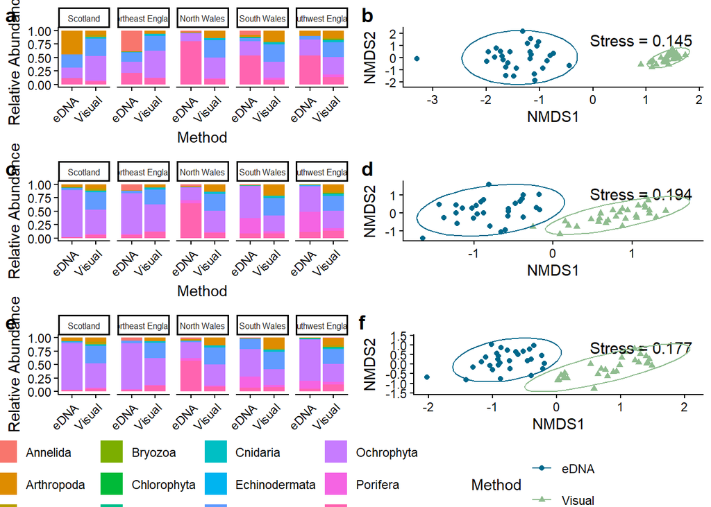

```r
# plot beta together
beta_all <- cowplot::plot_grid(
  species_stacked, NMDS_method_jaccard,
  genus_stacked, NMDS_method_jaccard_genus,
  family_stacked, NMDS_method_jaccard_family,
  legend_a, legend_b,
  labels = c("a", "b", "c", "d", "e", "f"),
  ncol = 2,
  align = "h",        # Align horizontally (y-axes)
  axis = "tb",        # Align y-axes (top-bottom, i.e., across rows)
  rel_heights = c(1,1,1,0.3)
)

ggsave(filename = "Figures/beta_all.png",
       plot = beta_all, device = "png", dpi = 300, units = "mm", height = 300, width = 250)

beta_all
```

Export for PRIMER 7.

```r
sample_data_PRIMER7 <- data.frame(sample_data(phylo_direct_combined_sp))
matrix_PRIMER7 <- data.frame(otu_table(phylo_direct_combined_sp))

write.csv(sample_data_PRIMER7, file = "Processed_Data/sample_data_PRIMER7.csv", row.names = TRUE)
write.csv(matrix_PRIMER7, file = "Processed_Data/matrix_PRIMER7.csv", row.names = TRUE)
```